# A4 - Análisis de varianza y repaso del curso

Mario Ubierna San Mamés

10 de junio, 2021

Importación de librerías:

```r
library(ggplot2)
library(nortest)
library(lsr)
library(agricolae)
```

# 1 Lectura del fichero y preparación de los datos

Leed el fichero trainCLEAN.csv y guardad los datos en un objeto con identificador denominado claim. A contiunación, verificad que los datos se han cargado correctamente.

```r
claim = read.csv(file = "./data/trainCLEAN.csv", sep = ",", stringsAsFactors = TRUE, na.strings = NA)

head(claim)
```

```
##   ClaimNumber   DateTimeOfAccident         DateReported Age Gender
## 1   WC8285054 2002-04-09T07:00:00Z 2002-07-05T00:00:00Z  48      M
## 2   WC6982224 1999-01-07T11:00:00Z 1999-01-20T00:00:00Z  43      F
## 3   WC5481426 1996-03-25T00:00:00Z 1996-04-14T00:00:00Z  30      M
## 4   WC9775968 2005-06-22T13:00:00Z 2005-07-22T00:00:00Z  41      M
## 5   WC2634037 1990-08-29T08:00:00Z 1990-09-27T00:00:00Z  36      M
## 6   WC6828422 1999-06-21T11:00:00Z 1999-09-09T00:00:00Z  50      M
##   MaritalStatus DependentChildren DependentsOther WeeklyWages PartTimeFullTime
## 1             M                 0               0      500.00                F
## 2             M                 0               0      509.34                F
## 3             U                 0               0      709.10                F
## 4             S                 0               0      555.46                F
## 5             M                 0               0      377.10                F
## 6             M                 0               0      200.00                F
##   HoursWorkedPerWeek DaysWorkedPerWeek
```

[output cut: 20 more lines]

Comprobamos los tipos de las variables y que se han cargado todas:

```r
str(claim)
```

```
## 'data.frame':    54000 obs. of  15 variables:
##  $ ClaimNumber              : Factor w/ 54000 levels "WC1592889","WC1592905",..: 42983 34374 24826 52548 6663 33451 41515 38079 18056 53393 ...
##  $ DateTimeOfAccident       : Factor w/ 36673 levels "1988-01-01T09:00:00Z",..: 28968 22374 16652 35569 5379 23346 27479 24758 12523 36560 ...
##  $ DateReported             : Factor w/ 6653 levels "1988-01-08T00:00:00Z",..: 5278 4020 3009 6390 986 4251 4931 4471 2291 6543 ...
##  $ Age                      : int  48 43 30 41 36 50 39 56 49 30 ...
##  $ Gender                   : Factor w/ 3 levels "F","M","U": 2 1 2 2 2 2 2 2 2 2 ...
##  $ MaritalStatus            : Factor w/ 4 levels "","M","S","U": 2 2 4 3 2 2 2 2 2 3 ...
##  $ DependentChildren        : int  0 0 0 0 0 0 0 0 0 0 ...
##  $ DependentsOther          : int  0 0 0 0 0 0 0 0 0 0 ...
##  $ WeeklyWages              : num  500 509 709 555 377 ...
##  $ PartTimeFullTime         : Factor w/ 2 levels "F","P": 1 1 1 1 1 1 1 1 1 1 ...
##  $ HoursWorkedPerWeek       : num  38 37.5 38 38 38 38 38 40 38 37 ...
##  $ DaysWorkedPerWeek        : int  5 5 5 5 5 5 5 5 5 5 ...
##  $ ClaimDescription         : Factor w/ 28114 levels "A BACK AND HIT HAND CRUSHED INJURY LEFT HAND",..: 14002 21205 3719 4266 16932 23153 7176 2803 10047 24225 ...
##  $ InitialIncurredCalimsCost: int  1500 5500 1700 15000 2800 500 500 500 925 1500 ...
##  $ UltimateIncurredClaimCost: num  4303 6106 2099 16283 3772 ...
```

Vemos que seguimos manteniendo las 15 variables iniciales, por lo que la lectura se ha realizado de forma correcta.

## 1.1 Preparación de los datos

Cambiamos el nombre de las variables a castellano. En concreto, se pide que se denominen de la siguiente forma: Id, Ocurrencia, Apertura, Edad, Sexo, Estado, Dependientes, OtrosDepend, Salario, Jornada, CosteInicio, CosteFinal, HorasSemana, DiasSemana y Descripcion:

```r
colnames(claim) = c("Id", "Ocurrencia", "Apertura", "Edad", "Sexo", "Estado", "Dependientes", "OtrosDepend", "Salario", "Jornada", "HorasSemana", "DiasSemana", "Descripcion", "CosteInicio", "CosteFinal")

str(claim)
```

```
## 'data.frame':    54000 obs. of  15 variables:
##  $ Id          : Factor w/ 54000 levels "WC1592889","WC1592905",..: 42983 34374 24826 52548 6663 33451 41515 38079 18056 53393 ...
##  $ Ocurrencia  : Factor w/ 36673 levels "1988-01-01T09:00:00Z",..: 28968 22374 16652 35569 5379 23346 27479 24758 12523 36560 ...
##  $ Apertura    : Factor w/ 6653 levels "1988-01-08T00:00:00Z",..: 5278 4020 3009 6390 986 4251 4931 4471 2291 6543 ...
##  $ Edad        : int  48 43 30 41 36 50 39 56 49 30 ...
##  $ Sexo        : Factor w/ 3 levels "F","M","U": 2 1 2 2 2 2 2 2 2 2 ...
##  $ Estado      : Factor w/ 4 levels "","M","S","U": 2 2 4 3 2 2 2 2 2 3 ...
##  $ Dependientes: int  0 0 0 0 0 0 0 0 0 0 ...
##  $ OtrosDepend : int  0 0 0 0 0 0 0 0 0 0 ...
##  $ Salario     : num  500 509 709 555 377 ...
##  $ Jornada     : Factor w/ 2 levels "F","P": 1 1 1 1 1 1 1 1 1 1 ...
##  $ HorasSemana : num  38 37.5 38 38 38 38 38 40 38 37 ...
##  $ DiasSemana  : int  5 5 5 5 5 5 5 5 5 5 ...
##  $ Descripcion : Factor w/ 28114 levels "A BACK AND HIT HAND CRUSHED INJURY LEFT HAND",..: 14002 21205 3719 4266 16932 23153 7176 2803 10047 24225 ...
##  $ CosteInicio : int  1500 5500 1700 15000 2800 500 500 500 925 1500 ...
##  $ CosteFinal  : num  4303 6106 2099 16283 3772 ...
```

### 1.1.1 Las variables ‘Ocurrencia‘ y ‘Apertura‘ están clasificadas como factor. Para poder trabajar con ellas hay que convertirlas en fechas:

```r
claim$Ocurrencia = as.Date(claim$Ocurrencia)
claim$Apertura = as.Date(claim$Apertura)

head(claim[, c("Ocurrencia", "Apertura")])
```

```
##   Ocurrencia   Apertura
## 1 2002-04-09 2002-07-05
## 2 1999-01-07 1999-01-20
## 3 1996-03-25 1996-04-14
## 4 2005-06-22 2005-07-22
## 5 1990-08-29 1990-09-27
## 6 1999-06-21 1999-09-09
```

### 1.1.2 Crear una variable denominada ‘tiempo‘ que contabilice en días el tiempo que tarda en abrirse un siniestro por la compañía desde su ocurrencia:

```r
claim$tiempo = as.integer(claim$Apertura - claim$Ocurrencia)

head(claim[, c("tiempo", "Ocurrencia", "Apertura")])
```

```
##   tiempo Ocurrencia   Apertura
## 1     87 2002-04-09 2002-07-05
## 2     13 1999-01-07 1999-01-20
## 3     20 1996-03-25 1996-04-14
## 4     30 2005-06-22 2005-07-22
## 5     29 1990-08-29 1990-09-27
## 6     80 1999-06-21 1999-09-09
```

## 1.2 Clasificación de tiempo

La variable tiempo indica la duración de apertura del siniestro de la siguiente forma: “Muy rápido” si se apertura en 15 días o menos, “Rápido” si se apertura entre 16 y 30 días, “Lento” si se apertura entre 31 y 89 días, y “Muy lento” si tarda 90 días o más en aperturarse el siniestro. Cread una variable categórica denominada Clasificacion, que clasifique el siniestro según estas categorías:

```r
claim$Clasificacion = as.factor(cut(claim$tiempo, breaks = c(-1, 15, 30, 89, 1095), labels = c("Muy rápido", "Rápido", "Lento", "Muy lento")))

head(claim[, c("tiempo", "Clasificacion")])
```

```
##   tiempo Clasificacion
## 1     87         Lento
## 2     13    Muy rápido
## 3     20        Rápido
## 4     30        Rápido
## 5     29        Rápido
## 6     80         Lento
```

## 1.3 Valores ausentes

### 1.3.1 Analizad el número de categorías distintas en las variables ‘Descripcion‘, ‘Sexo‘ y ‘Estado‘. ¿Cuántas descripciones distintas hay de los siniestros?

```r
summary(claim)
```

```
##          Id          Ocurrencia            Apertura               Edad
##  WC1592889:    1   Min.   :1988-01-01   Min.   :1988-01-08   Min.   :13.00
##  WC1592905:    1   1st Qu.:1992-06-30   1st Qu.:1992-08-04   1st Qu.:23.00
##  WC1592998:    1   Median :1997-01-07   Median :1997-02-16   Median :32.00
##  WC1593292:    1   Mean   :1997-01-02   Mean   :1997-02-11   Mean   :33.84
##  WC1593727:    1   3rd Qu.:2001-07-09   3rd Qu.:2001-08-25   3rd Qu.:43.00
##  WC1593868:    1   Max.   :2005-12-31   Max.   :2006-09-23   Max.   :81.00
##  (Other)  :53994
##  Sexo      Estado     Dependientes     OtrosDepend          Salario
##  F:12338    :   29   Min.   :0.0000   Min.   :0.000000   Min.   :   1.0
##  M:41660   M:22516   1st Qu.:0.0000   1st Qu.:0.000000   1st Qu.: 200.0
##  U:    2   S:26161   Median :0.0000   Median :0.000000   Median : 392.2
##            U: 5294   Mean   :0.1192   Mean   :0.009944   Mean   : 416.4
##                      3rd Qu.:0.0000   3rd Qu.:0.000000   3rd Qu.: 500.0
##                      Max.   :9.0000   Max.   :5.000000   Max.   :7497.0
##
##  Jornada    HorasSemana       DiasSemana
##  F:49112   Min.   :  0.00   Min.   :1.000
##  P: 4888   1st Qu.: 38.00   1st Qu.:5.000
##            Median : 38.00   Median :5.000
##            Mean   : 37.74   Mean   :4.906
##            3rd Qu.: 40.00   3rd Qu.:5.000
##            Max.   :640.00   Max.   :7.000
##
##                                         Descripcion     CosteInicio
##  SLIPPED ON ROLLER TENDONITIS RIGHT SHOULDER  :  289   Min.   :      1
##  SORTING ALUMINIUM BARS STRAIN SHOULDER NECK  :  278   1st Qu.:    700
##  SLIPPED USING LATHE IN EYE CORNEA            :  258   Median :   2000
##  REDBACK SPIDER BITE RIGHT FOOT RIGHT FRACTURE:  256   Mean   :   7841
##  LIFTING TYRES LOWER BACK STRAIN              :  255   3rd Qu.:   9500
##  LIFTING BACK STRAIN LOWER BACK STRAIN        :  253   Max.   :2000000
##  (Other)                                      :52411
##    CosteFinal            tiempo           Clasificacion
##  Min.   :      5.7   Min.   :   0.00   Muy rápido:16954
##  1st Qu.:   1128.7   1st Qu.:  14.00   Rápido    :17867
##  Median :   3179.1   Median :  22.00   Lento     :14785
##  Mean   :  10195.5   Mean   :  39.31   Muy lento : 4394
##  3rd Qu.:   8900.1   3rd Qu.:  41.00
##  Max.   :1570535.8   Max.   :1095.00
##
```

En cuanto a la variable Sexo, hay tres categorías: F, M y U. Éste último tipo nos indica que se desconoce si es de género femenino o masculino.

Finalmente, la variable Estado hay cuatro tipos: Sin valor (NA), M, S y U. Al igual que antes este último tipo nos indica que es deconocido el estado para dicha observación.

### 1.3.2 Representad los observaciones con la categoría “U” (U=unknown) en las variables ‘Sexo‘y ‘Estado‘ como missings.

```r
claim[claim$Sexo == "U", "Sexo"] = NA
claim[claim$Estado == "U", "Estado"] = NA
```

Comprobamos que se han realizado los cambios:

```r
summary(claim$Sexo)
```

```
##     F     M     U  NA's
## 12338 41660     0     2
```

```r
summary(claim$Estado)
```

```
##           M     S     U  NA's
##    29 22516 26161     0  5294
```

Ahora vemos que ya tenemos todos los valores perdidos como NA.

### 1.3.3 Comprobad la proporción de observaciones que tienen valores ausentes y sacad conclusiones sobre cómo de serio es el problema de valores ausentes en estos datos.

En el anterior apartado hemos visto que hay 2 observaciones con valor NA para la variable Sexo, realmente son observaciones insignificantes ya que hay un total de 54000 registros y solo dos son NA. Por lo que, podríamos eliminar dichas observaciones sin problemas.

Respecto a la variable Estado vemos que tenemos más registros como NA, para ser más exactos hay 5294 observaciones de un total de 54000 registros, esto representa un 9.8% de los datos, es decir, en este caso sí que es significativo. Podríamos crear un modelo de regresión lineal para predecir dicho valor, imputar el valor más frecuente, pero en el siguiente apartado se nos pide que se eliminen dichas observaciones.

### 1.3.4 Eliminad los valores ausentes del conjunto de datos. Denominamos al conjunto de datos claimNet.

Ejecutamos el summary para ver qué variables tienen valores ausentes, los cuales son distintos de los missings, los primeros son aquellos en los que no viene un valor, mientras que lo segundo sí que viene un valor pero es del tipo unknown:

```r
summary(claim)
```

```
##          Id          Ocurrencia            Apertura               Edad
##  WC1592889:    1   Min.   :1988-01-01   Min.   :1988-01-08   Min.   :13.00
##  WC1592905:    1   1st Qu.:1992-06-30   1st Qu.:1992-08-04   1st Qu.:23.00
##  WC1592998:    1   Median :1997-01-07   Median :1997-02-16   Median :32.00
##  WC1593292:    1   Mean   :1997-01-02   Mean   :1997-02-11   Mean   :33.84
##  WC1593727:    1   3rd Qu.:2001-07-09   3rd Qu.:2001-08-25   3rd Qu.:43.00
##  WC1593868:    1   Max.   :2005-12-31   Max.   :2006-09-23   Max.   :81.00
##  (Other)  :53994
##    Sexo        Estado       Dependientes     OtrosDepend          Salario
##  F   :12338       :   29   Min.   :0.0000   Min.   :0.000000   Min.   :   1.0
##  M   :41660   M   :22516   1st Qu.:0.0000   1st Qu.:0.000000   1st Qu.: 200.0
##  U   :    0   S   :26161   Median :0.0000   Median :0.000000   Median : 392.2
##  NA's:    2   U   :    0   Mean   :0.1192   Mean   :0.009944   Mean   : 416.4
##               NA's: 5294   3rd Qu.:0.0000   3rd Qu.:0.000000   3rd Qu.: 500.0
##                            Max.   :9.0000   Max.   :5.000000   Max.   :7497.0
##
##  Jornada    HorasSemana       DiasSemana
##  F:49112   Min.   :  0.00   Min.   :1.000
##  P: 4888   1st Qu.: 38.00   1st Qu.:5.000
##            Median : 38.00   Median :5.000
##            Mean   : 37.74   Mean   :4.906
##            3rd Qu.: 40.00   3rd Qu.:5.000
##            Max.   :640.00   Max.   :7.000
##
##                                         Descripcion     CosteInicio
##  SLIPPED ON ROLLER TENDONITIS RIGHT SHOULDER  :  289   Min.   :      1
##  SORTING ALUMINIUM BARS STRAIN SHOULDER NECK  :  278   1st Qu.:    700
##  SLIPPED USING LATHE IN EYE CORNEA            :  258   Median :   2000
##  REDBACK SPIDER BITE RIGHT FOOT RIGHT FRACTURE:  256   Mean   :   7841
##  LIFTING TYRES LOWER BACK STRAIN              :  255   3rd Qu.:   9500
##  LIFTING BACK STRAIN LOWER BACK STRAIN        :  253   Max.   :2000000
##  (Other)                                      :52411
##    CosteFinal            tiempo           Clasificacion
##  Min.   :      5.7   Min.   :   0.00   Muy rápido:16954
##  1st Qu.:   1128.7   1st Qu.:  14.00   Rápido    :17867
##  Median :   3179.1   Median :  22.00   Lento     :14785
##  Mean   :  10195.5   Mean   :  39.31   Muy lento : 4394
##  3rd Qu.:   8900.1   3rd Qu.:  41.00
##  Max.   :1570535.8   Max.   :1095.00
##
```

De la anterior ejecución vemos que la variable Estado tiene 29 como vacíos (valores ausentes), por lo que procedemos la eliminación de dichos registros, también elimanos las observaciones cuyo valores sea NA:

```r
claimNet = claim[claim$Estado != "", ]
claimNet = claimNet[!is.na(claimNet$Estado),]
claimNet = claimNet[!is.na(claimNet$Sexo),]

summary(claimNet)
```

```
##          Id          Ocurrencia            Apertura               Edad
##  WC1592889:    1   Min.   :1988-01-01   Min.   :1988-01-08   Min.   :13.00
##  WC1592905:    1   1st Qu.:1992-06-04   1st Qu.:1992-07-10   1st Qu.:23.00
##  WC1592998:    1   Median :1997-02-18   Median :1997-03-26   Median :32.00
##  WC1593292:    1   Mean   :1997-01-03   Mean   :1997-02-12   Mean   :33.67
##  WC1593727:    1   3rd Qu.:2001-07-05   3rd Qu.:2001-08-22   3rd Qu.:42.00
##  WC1593868:    1   Max.   :2005-12-31   Max.   :2006-09-23   Max.   :80.00
##  (Other)  :48669
##  Sexo      Estado     Dependientes   OtrosDepend         Salario
##  F:11257    :    0   Min.   :0.00   Min.   :0.00000   Min.   :   1.0
##  M:37418   M:22514   1st Qu.:0.00   1st Qu.:0.00000   1st Qu.: 200.0
##  U:    0   S:26161   Median :0.00   Median :0.00000   Median : 381.1
##            U:    0   Mean   :0.13   Mean   :0.01058   Mean   : 408.7
##                      3rd Qu.:0.00   3rd Qu.:0.00000   3rd Qu.: 500.0
##                      Max.   :9.00   Max.   :5.00000   Max.   :7497.0
##
##  Jornada    HorasSemana       DiasSemana
##  F:44271   Min.   :  0.00   Min.   :1.000
##  P: 4404   1st Qu.: 38.00   1st Qu.:5.000
##            Median : 38.00   Median :5.000
##            Mean   : 37.75   Mean   :4.908
##            3rd Qu.: 40.00   3rd Qu.:5.000
##            Max.   :640.00   Max.   :7.000
##
##                                         Descripcion     CosteInicio
##  SLIPPED ON ROLLER TENDONITIS RIGHT SHOULDER  :  259   Min.   :      1
##  REDBACK SPIDER BITE RIGHT FOOT RIGHT FRACTURE:  244   1st Qu.:    650
##  SORTING ALUMINIUM BARS STRAIN SHOULDER NECK  :  240   Median :   2000
##  LIFTING BACK STRAIN LOWER BACK STRAIN        :  238   Mean   :   7454
##  SLIPPED USING LATHE IN EYE CORNEA            :  235   3rd Qu.:   9000
##  LIFTING TYRES LOWER BACK STRAIN              :  231   Max.   :2000000
##  (Other)                                      :47228
##    CosteFinal            tiempo           Clasificacion
##  Min.   :      5.7   Min.   :   0.00   Muy rápido:14789
##  1st Qu.:   1067.9   1st Qu.:  14.00   Rápido    :16237
##  Median :   2982.0   Median :  23.00   Lento     :13589
##  Mean   :   9704.6   Mean   :  39.87   Muy lento : 4060
##  3rd Qu.:   8349.6   3rd Qu.:  42.00
##  Max.   :1570535.8   Max.   :1091.00
##
```

Vemos que ahora el dataset ha pasado de 54000 registros a 48675.

## 1.4 Saluda mental

La compañía está preocupada por las bajas por salud mental. Por este motivo, quiere monitorizar las bajas que incluyan las palabras Stress, Anxiety, Harassment o Depression. Se pide:

### 1.4.1 Crear la variable dicotómica denominada ‘RiesgoSM‘ si la variable ‘Descripcion‘ incluye alguna de estas palabras.

Lo primero de todo es definir la función que nos devuelve un vector con la variable dicotimizada, un 1 si encuentra la palabra en la descripción o 0 en caso contrario:

```r
getRiesgoSM = function(descripciones) {
  riesgoSM = c()

  for (desc in descripciones) {
    if (grepl("STRESS", toupper(desc)) == TRUE ||
        grepl("ANXIETY", toupper(desc)) == TRUE ||
        grepl("HARASSMENT", toupper(desc)) == TRUE ||
        grepl("DEPRESSION", toupper(desc)) == TRUE) {
     riesgoSM[length(riesgoSM) + 1] = 1
   } else {
     riesgoSM[length(riesgoSM) + 1] = 0
   }
  }

  return(riesgoSM)
}
```

Una vez definida la función la llamamos y creamos la variables en el dataframe:

```r
claimNet$RiesgoSM = getRiesgoSM(claimNet$Descripcion)

#La convertimos a factor
claimNet$RiesgoSM = as.factor(claimNet$RiesgoSM)

# Comprobamos que se ha creado correctamente
str(claimNet)
```

```
## 'data.frame':    48675 obs. of  18 variables:
##  $ Id           : Factor w/ 54000 levels "WC1592889","WC1592905",..: 42983 34374 52548 6663 33451 41515 38079 18056 53393 9395 ...
##  $ Ocurrencia   : Date, format: "2002-04-09" "1999-01-07" ...
##  $ Apertura     : Date, format: "2002-07-05" "1999-01-20" ...
##  $ Edad         : int  48 43 41 36 50 39 56 49 30 20 ...
##  $ Sexo         : Factor w/ 3 levels "F","M","U": 2 1 2 2 2 2 2 2 2 2 ...
##  $ Estado       : Factor w/ 4 levels "","M","S","U": 2 2 3 2 2 2 2 2 3 3 ...
##  $ Dependientes : int  0 0 0 0 0 0 0 0 0 0 ...
##  $ OtrosDepend  : int  0 0 0 0 0 0 0 0 0 0 ...
##  $ Salario      : num  500 509 555 377 200 ...
##  $ Jornada      : Factor w/ 2 levels "F","P": 1 1 1 1 1 1 1 1 1 1 ...
##  $ HorasSemana  : num  38 37.5 38 38 38 38 40 38 37 40 ...
##  $ DiasSemana   : int  5 5 5 5 5 5 5 5 5 5 ...
##  $ Descripcion  : Factor w/ 28114 levels "A BACK AND HIT HAND CRUSHED INJURY LEFT HAND",..: 14002 21205 4266 16932 23153 7176 2803 10047 24225 21605 ...
##  $ CosteInicio  : int  1500 5500 15000 2800 500 500 500 925 1500 3500 ...
##  $ CosteFinal   : num  4303 6106 16283 3772 747 ...
##  $ tiempo       : int  87 13 30 29 80 10 38 33 15 11 ...
##  $ Clasificacion: Factor w/ 4 levels "Muy rápido","Rápido",..: 3 1 2 2 3 1 3 3 1 1 ...
##  $ RiesgoSM     : Factor w/ 2 levels "0","1": 1 1 1 1 1 1 1 1 1 1 ...
```

## 1.5 Análisis visual

Mostrad con diversos diagramas de caja la distribución de la variable ‘CosteFinal‘ en escala logarítmica según la variable ‘Sexo‘, según ‘Estado‘, según ‘Clasificacion‘ y según ‘RiesgoSM‘. E interpretad los gráficos brevemente.

Lo primero de todo es crear una nueva variable para convertir a escala logarítmica el CosteFinal:

```r
claimNet$LogCosteFinal = log(claimNet$CosteFinal)

summary(claimNet)
```

```
##          Id          Ocurrencia            Apertura               Edad
##  WC1592889:    1   Min.   :1988-01-01   Min.   :1988-01-08   Min.   :13.00
##  WC1592905:    1   1st Qu.:1992-06-04   1st Qu.:1992-07-10   1st Qu.:23.00
##  WC1592998:    1   Median :1997-02-18   Median :1997-03-26   Median :32.00
##  WC1593292:    1   Mean   :1997-01-03   Mean   :1997-02-12   Mean   :33.67
##  WC1593727:    1   3rd Qu.:2001-07-05   3rd Qu.:2001-08-22   3rd Qu.:42.00
##  WC1593868:    1   Max.   :2005-12-31   Max.   :2006-09-23   Max.   :80.00
##  (Other)  :48669
##  Sexo      Estado     Dependientes   OtrosDepend         Salario
##  F:11257    :    0   Min.   :0.00   Min.   :0.00000   Min.   :   1.0
##  M:37418   M:22514   1st Qu.:0.00   1st Qu.:0.00000   1st Qu.: 200.0
##  U:    0   S:26161   Median :0.00   Median :0.00000   Median : 381.1
##            U:    0   Mean   :0.13   Mean   :0.01058   Mean   : 408.7
##                      3rd Qu.:0.00   3rd Qu.:0.00000   3rd Qu.: 500.0
##                      Max.   :9.00   Max.   :5.00000   Max.   :7497.0
##
##  Jornada    HorasSemana       DiasSemana
##  F:44271   Min.   :  0.00   Min.   :1.000
##  P: 4404   1st Qu.: 38.00   1st Qu.:5.000
##            Median : 38.00   Median :5.000
##            Mean   : 37.75   Mean   :4.908
##            3rd Qu.: 40.00   3rd Qu.:5.000
##            Max.   :640.00   Max.   :7.000
##
##                                         Descripcion     CosteInicio
##  SLIPPED ON ROLLER TENDONITIS RIGHT SHOULDER  :  259   Min.   :      1
##  REDBACK SPIDER BITE RIGHT FOOT RIGHT FRACTURE:  244   1st Qu.:    650
##  SORTING ALUMINIUM BARS STRAIN SHOULDER NECK  :  240   Median :   2000
##  LIFTING BACK STRAIN LOWER BACK STRAIN        :  238   Mean   :   7454
##  SLIPPED USING LATHE IN EYE CORNEA            :  235   3rd Qu.:   9000
##  LIFTING TYRES LOWER BACK STRAIN              :  231   Max.   :2000000
##  (Other)                                      :47228
##    CosteFinal            tiempo           Clasificacion   RiesgoSM
##  Min.   :      5.7   Min.   :   0.00   Muy rápido:14789   0:48459
##  1st Qu.:   1067.9   1st Qu.:  14.00   Rápido    :16237   1:  216
##  Median :   2982.0   Median :  23.00   Lento     :13589
##  Mean   :   9704.6   Mean   :  39.87   Muy lento : 4060
##  3rd Qu.:   8349.6   3rd Qu.:  42.00
##  Max.   :1570535.8   Max.   :1091.00
##
##  LogCosteFinal
##  Min.   : 1.747
##  1st Qu.: 6.973
##  Median : 8.000
##  Mean   : 8.003
##  3rd Qu.: 9.030
##  Max.   :14.267
##
```

Una vez que ya tenemos la variable CosteFinal en escala logarítmica, hacemos el análisis de la misma respecto al sexo:

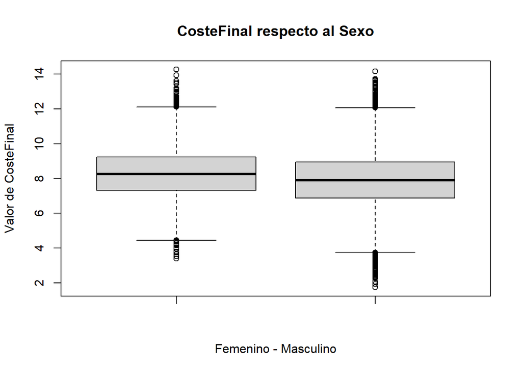

```r
boxplot(claimNet[claimNet$Sexo == "F", "LogCosteFinal"],
        claimNet[claimNet$Sexo == "M", "LogCosteFinal"],
        main = "CosteFinal respecto al Sexo",
        xlab = "Femenino - Masculino",
        ylab = "Valor de CosteFinal"
        )
```

Del anterior gráfico podemos observar que el género femenino tiene un valor mínimo algo mayor que el masculino, es por ello que su mediana es un pelín más elevada, esto lo que significa es que de media las mujeres tienen un CosteFinal algo mayor, en otras palabras la indemnización suele ser algo mayor si eres mujer.

Por otro lado, observamos que hay bastantes valores atípicos en los dos sexos, pero especialemnte más en el masculino, es decir, suele haber más casos “especiales” si eres hombre que si eres mujer.

Continuiamos analizando el CosteFinal, pero ahora respecto a el estado civil:

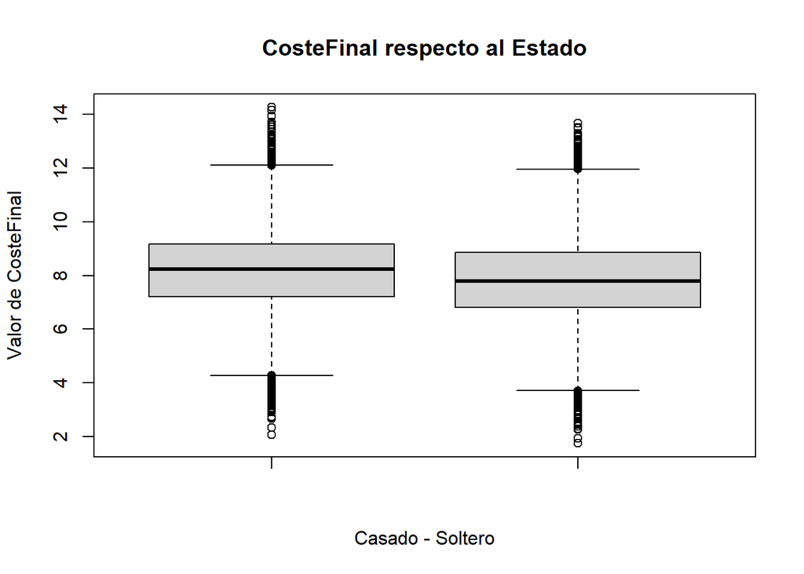

```r
boxplot(claimNet[claimNet$Estado == "M", "LogCosteFinal"],
        claimNet[claimNet$Estado == "S", "LogCosteFinal"],
        main = "CosteFinal respecto al Estado",
        xlab = "Casado - Soltero",
        ylab = "Valor de CosteFinal"
        )
```

En este caso, vemos que sucede algo parecido, si eres casado tu valor en el límite inferior es algo mayor que si estás soltero haciendo que la mediana sea algo mayor, es decir, si estás casado sueles obtener una mejor indemnización que si estás soltero.

Por otro lado, vemos que también hay muchos valores atípicos, pero en este caso está bastante bien equilibrado entre ambos grupos.

Analizamos el CosteFinal según la variable Clasificación:

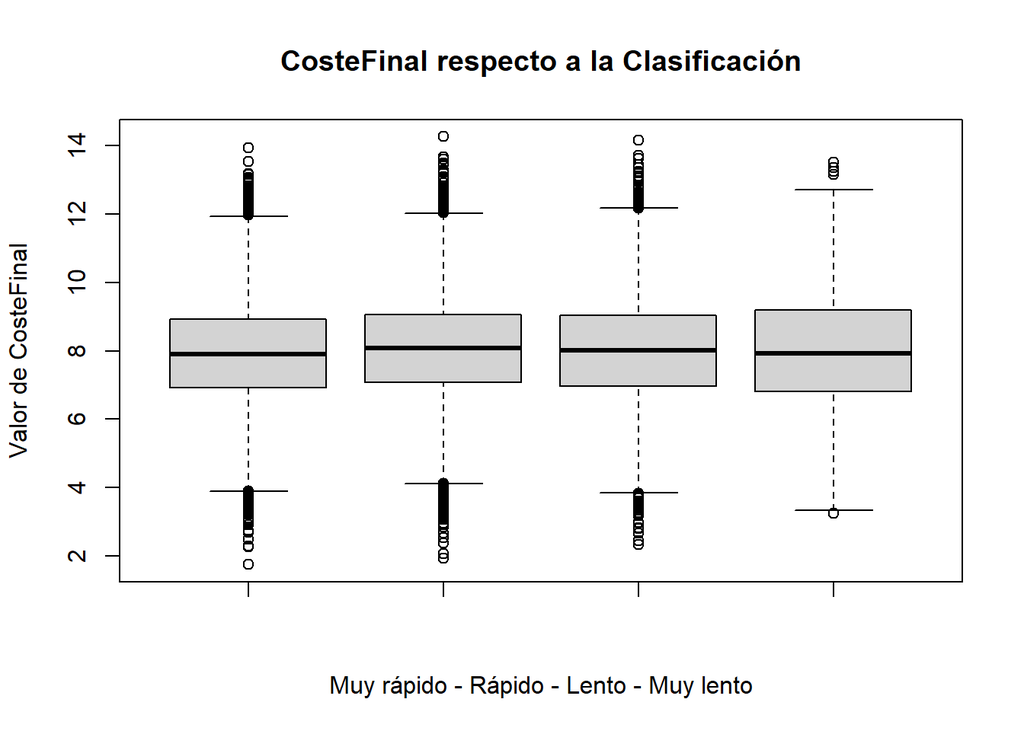

```r
boxplot(claimNet[claimNet$Clasificacion == "Muy rápido", "LogCosteFinal"],
        claimNet[claimNet$Clasificacion == "Rápido", "LogCosteFinal"],
        claimNet[claimNet$Clasificacion == "Lento", "LogCosteFinal"],
        claimNet[claimNet$Clasificacion == "Muy lento", "LogCosteFinal"],
        main = "CosteFinal respecto a la Clasificación",
        xlab = "Muy rápido - Rápido - Lento - Muy lento",
        ylab = "Valor de CosteFinal"
        )
```

El anterior gráfico es muy interesante, ya que nos indica que si la duración de apertura del siniestro es muy lenta, podemos entender que se realiza un estudio muy detallado, por lo que apenas tenemos valores atípicos y éstos están muy bien contralados. Sin embargo, con el resto de variables sucede todo lo contrario.

También es curioso ver que si la clasificación es rápida tiende a tener una mayor indemnización, es decir, el coste que le supone a la asegurado es mayor, esto lo apreciamos gracias a la mediana correspondiente.

Por último, vamos a analizar el CosteFinal según el RiesgoSM:

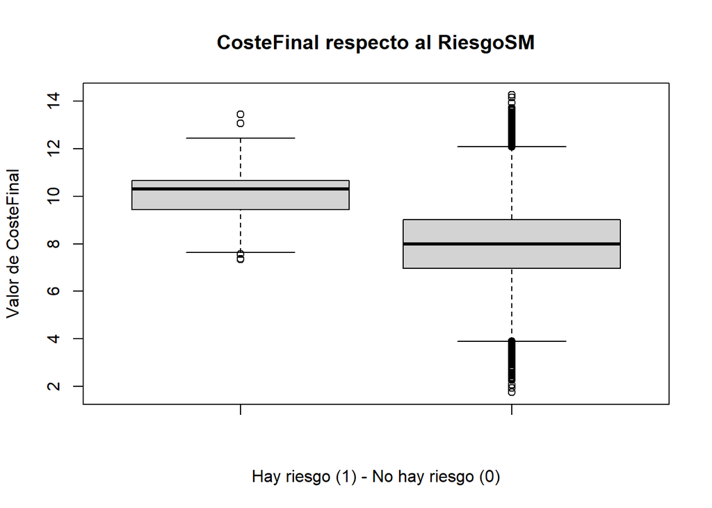

```r
boxplot(claimNet[claimNet$RiesgoSM == "1", "LogCosteFinal"],
        claimNet[claimNet$RiesgoSM == "0", "LogCosteFinal"],
        main = "CosteFinal respecto al RiesgoSM",
        xlab = "Hay riesgo (1) - No hay riesgo (0)",
        ylab = "Valor de CosteFinal"
        )
```

Este gráfico es el más llamativo de todos ya que en los anteriores estaban más o menos nivelados, pero en este caso vemos que el riesgo de padecer un enfermedad de salud mental influye bastante en el coste final, siendo el límite inferior más elevado y su mediana también.

Por otro lado, si no hay riesgo tenemos más valores atípicos, es decir, hay más situacioens “especiales” que por los motivos que sean se dan una indemnización mayor o menor.

## 1.6 Comprobación de normalidad

¿Podemos asumir que la variable CosteFinal tiene una distribución normal? Debéis justificar la respuesta a partir de métodos visuales y contrastes.

### 1.6.1 Realizad la insepección visual de normalidad de CosteFinal

Lo primero de todo es analizar la variables CosteFinal de forma gráfica:

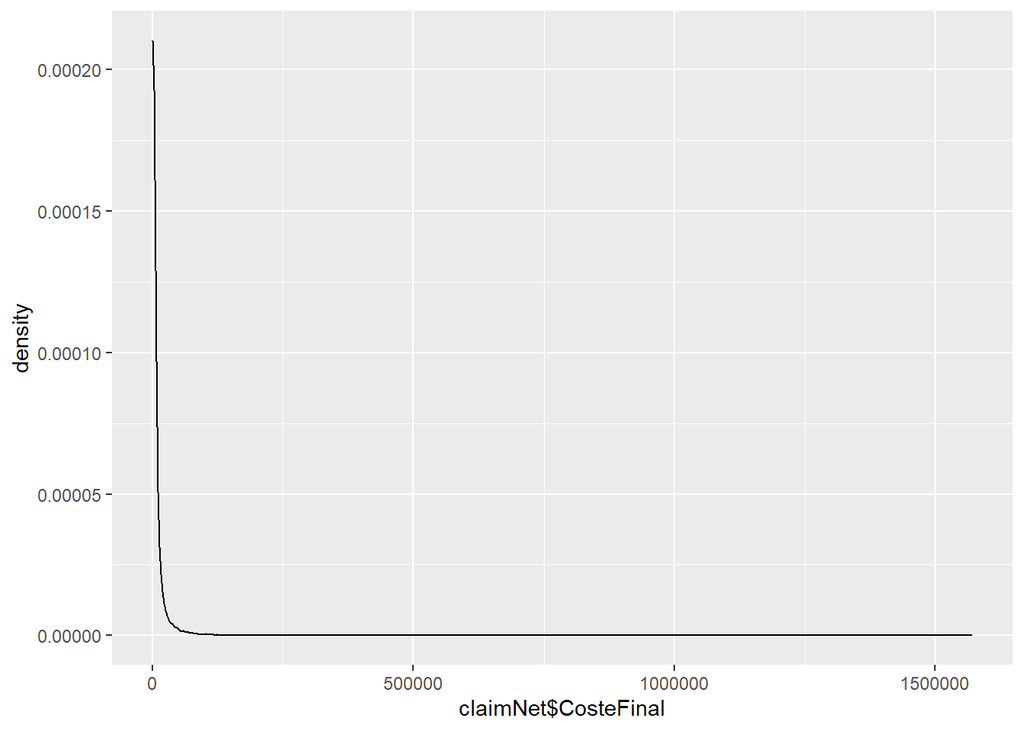

```r
ggplot(mapping = aes(x=claimNet$CosteFinal)) + geom_density()
```

Como podemos apreciar de la anterior ilustración, CosteFinal no sigue una distribución normal, pero vamos a anilizarlo en el siguiente punto a partir de un test.

### 1.6.2 Realizad contraste de normalidad de Lilliefors de CosteFinal

Aplicamos el test de Lilliefors, en dicho test la hipótesis nula es que la variable sigue una distribución norma, y la alternativa en caso contrario:

```r
lillie.test(claimNet$CosteFinal)
```

```
##
##  Lilliefors (Kolmogorov-Smirnov) normality test
##
## data:  claimNet$CosteFinal
## D = 0.36734, p-value < 2.2e-16
```

Como nos da un pvalue más pequeño que alfa (0.05), es decir, pvalue < alfa, podemos rechazar la hipótesis nula a favor de la alternativa, es decir, que nuestra variable no sigue una distribución normal.

### 1.6.3 Realizad la insepección visual de normalidad de CosteFinal en escala logarítmica

Realizamos el mismo gráfico que antes pero para la variable LogCosteFinal:

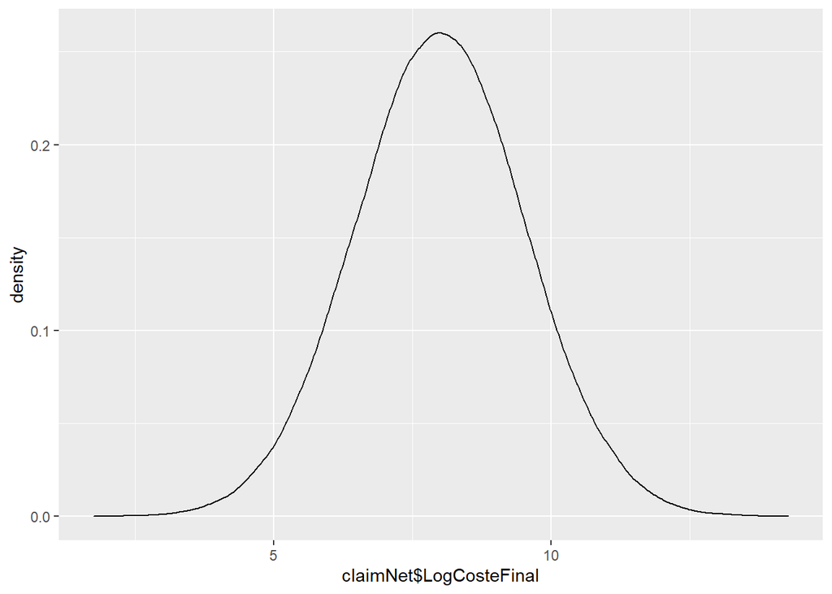

```r
ggplot(mapping = aes(x=claimNet$LogCosteFinal)) + geom_density()
```

Como podemos apreciar, a priori cuando escalamos la variable logarítmica sí que sigue una distribución normal, pero para confirmarlo ejecutamos el mismo test que en el caso anterior.

### 1.6.4 Realizad contraste de normalidad de Lilliefors de CosteFinal en escala logarítmica

Volvemos a aplicar el test de Lilliefors:

```r
lillie.test(claimNet$LogCosteFinal)
```

```
##
##  Lilliefors (Kolmogorov-Smirnov) normality test
##
## data:  claimNet$LogCosteFinal
## D = 0.0018307, p-value = 0.9579
```

En este caso nos da un pvalue mayor que alfa, es decir, pvalue > 0.05, por lo tanto podemos asegurar que la variable CosteFinal en escala logarítmica sigue una distribución normal.

# 2 Estadística inferencial

Utilizando el conjunto de datos claimNet.

## 2.1 Intervalo de confianza de la media poblacional de la variable CosteFinal

Calculad manualmente el intervalo de confianza al 95% de la media poblacional de la variable ‘CosteFinal‘ en escala normal (No se pueden utilizar funciones como t.test o z.test para el cálculo). A partir del resultado obtenido, explicad cómo se interpreta el intervalor de confianza.

Al realizar este ejercicio no se nos proporciona la varianza poblacional por lo que tenemos que calcular la varianza o la desviación de la muestra, esto lógicamente supone más incertidumbre ya que calculamos la desviación a partir de la muestra no de la población, es por ello que se recomienda hacer el cálculo a partir de la distribución t-student.

Por lo tanto, lo primero que vamos a hacer es calcular la media y la desviación de la muestra:

```r
media_muestra = mean(claimNet$CosteFinal)
sd_muestra = sd(claimNet$CosteFinal)
```

Lo segundo es definir nuestra alfa (nivel de significancia) y el tamaño de la muestra:

```r
alfa = 1 - 0.95
tam_muestra = length(claimNet$CosteFinal)
```

Calculamos el estadístico correspondiente:

```r
estadistico = sd_muestra / sqrt(tam_muestra)
z = qt(alfa/2, tam_muestra - 1, lower.tail = FALSE)
```

Finalmente, calculamos los límites:

```r
lim_inferior = round(media_muestra - (z * estadistico), 2)
lim_superior = round(media_muestra + (z * estadistico), 2)

cat("El límite inferior del intervalo de confianza (L) es igual a: ", lim_inferior)
```

```
## El límite inferior del intervalo de confianza (L) es igual a:  9450.34
```

```r
cat("El límite superior del intervalo de confianza (U) es igual a: ", lim_superior)
```

```
## El límite superior del intervalo de confianza (U) es igual a:  9958.82
```

De la anterior ejecución observamos que el intervalo de confianza es [9450.34, 9958.82]. Cuando calculamos el intervalo de confianza no podemos afirmar que cualquier valor de la población esté dentro del intervalo, lo que conseguimos definir al calcular el intervalo de confianza es asegurarnos, en nuestro caso a un 95%, del procedimiento, es decir, que el nivel de confianza en el procedimiento de cualquier muestra esté garantizado dando lugar a un intervalo que contenga el valor.

Resumiendo, de lo que nos garantizamos es que el 95% de los intervalos de confianza calculados a partir de cada muestra contengan el valor del CosteFinal.

## 2.2 Contraste de hipótesis para la diferencia de medias

¿Podemos aceptar que la indemnización a las mujeres supera en más de 1000 EUR la de los hombres? Responded a la pregunta utilizando un nivel de confianza del 95%.

Nota: se deben realizar los cálculos manualmente. No se pueden usar funciones de R que calculen directamente el contraste como t.test o similar. Sí se pueden usar funciones como mean, sd, qnorm, pnorm, qt y pt.

### 2.2.1 Escribid la hipótesis nula y la alternativa

En este caso, presentamos las siguientes hipótesis:

- H0 (hipótesis nula): media_CosteFinal_Mujeres = (media_CosteFinal_Hombres + 1000)
- H1 (hipótesis alternativa): media_CosteFinal_Mujeres > (media_CosteFinal_Hombres + 1000)

### 2.2.2 Justificación del test a aplicar

En este problema tenemos questión a responder y presenta las siguientes características:

- El contraste es de dos muestras, por un lado está la muestra de las mujeres y por otro el de hombres. Estas muestras son independientes no hay una relación entre sí.
- Sí que podemos asumir normalidad, es decir, podemos aplicar el Teorema del Límite Central, éste nos dice que si la media de una muestra es lo suficientemente grande (mayor que 30 observaciones) sigue una distribución normal. Al poder calcular la media de ambas muestras solo nos falta comprobar el tamaño de las mismas:

```r
claimNet_femenino = claimNet[claimNet$Sexo == "F",]
claimNet_masculino = claimNet[claimNet$Sexo == "M",]

cat("El número de observaciones del sexo femenino es: ", nrow(claimNet_femenino))
```

```
## El número de observaciones del sexo femenino es:  11257
```

```r
cat("El número de observaciones del sexo masculino es: ", nrow(claimNet_masculino))
```

```
## El número de observaciones del sexo masculino es:  37418
```

- El test es paramétrico, éstos se basan en que los datos siguen una determinada distribución, por norma general que siguen una distribución normal, por lo que tal y como hemos visto en el punto anterior podemos asumir la normalidad de los datos.
- El problema es unilateral por la derecha, ésto nos lo determina la hipótesis alternativa, ya que al tener el símbolo “>” mayor que, solo aceptamos la hipótesis alternativa si el valor observado es mayor que el valor crítico.
- Respecto a si es homocedasticidad o heterocedasticidad hacemos uso de la función var.test y comprobamos si el p-valor es menor que alfa (nivel de signifancia), en nuestro caso si p-valor < alfa (0.05) rechazamos la hipótesis nula siendo ésta que las varianzas son iguales, tal y como podemos ver a continuación el p-valor es menor que alfa, por lo que rechazamos la hipótesis nula, lo cual significa que estamos en un caso de heterocedasticidad:

```r
var.test(claimNet_femenino$CosteFinal, claimNet_masculino$CosteFinal, conf.level = 0.95)
```

```
##
##  F test to compare two variances
##
## data:  claimNet_femenino$CosteFinal and claimNet_masculino$CosteFinal
## F = 1.5751, num df = 11256, denom df = 37417, p-value < 2.2e-16
## alternative hypothesis: true ratio of variances is not equal to 1
## 95 percent confidence interval:
##  1.529015 1.622911
## sample estimates:
## ratio of variances
##           1.575073
```

### 2.2.3 Cálculos

Realizad los cálculos del estadístico de contraste, valor crítico y valor p con un nivel de confianza del 95%.

Lo primero de todo es definir la función que nos calcula el estadístico, el valor crítico y el pvalor:

```r
muestrasIndependientes_varianzasDesconocidas = function(valores_fem, valores_masc, alfa) {

  # Calculamos el estadístico de contraste
  sd_fem = sd(valores_fem)
  sd_masc = sd(valores_masc)
  n_fem = length(valores_fem)
  n_masc = length(valores_masc)

  # -1000 porque se indica en la hipótesis media_CosteFinal_Mujeres > (media_CosteFinal_Hombres + 1000)
  numerador = mean(valores_fem) - mean(valores_masc) - 1000
  denominador = sqrt(((sd_fem)^2/n_fem) + ((sd_masc)^2/n_masc))

  z_obs = numerador / denominador

  # Calculamos los grados de libertad
  numerador = (((sd_fem)^2/n_fem) + ((sd_masc)^2/n_masc))^2
  denominador = (((sd_fem)^2/n_fem)^2 / (n_fem - 1)) + (((sd_masc)^2/n_masc)^2 / (n_masc - 1))
  grados_libertad = as.integer(numerador / denominador)

  # Calculamos el punto crítico
  z_cri = qt(alfa, df = grados_libertad, lower.tail = FALSE)

  # Calculamos el p-valor
  p_value = pt(z_obs, df = grados_libertad, lower.tail = FALSE)

  # Devolvemos los valores
  return(data.frame(L = "-INF", U = z_cri, Estadistico_Contraste = z_obs, P_Valor = p_value, Grados_Libertad = grados_libertad))
}
```

Una vez definida la función la llamamos para obtener los resultados:

```r
muestrasIndependientes_varianzasDesconocidas(claimNet_femenino$CosteFinal, claimNet_masculino$CosteFinal, 0.05)
```

```
##      L       U Estadistico_Contraste      P_Valor Grados_Libertad
## 1 -INF 1.64495              3.591609 0.0001648202           15793
```

### 2.2.4 Interpretación del test

Podemos interpretar el test de dos formas distintas:

- La primera, comprobamos si el valor observado está fuera de la región de aceptación, si está fuera podemos rechazar la hipótesis nula en favor de la alternativa. En nuestro caso, la región de aceptación es el intervalo [-INF, 1.64495] y el valor observado 3.591609, como el valor observado está fuera de la región de aceptación rechazamos la hipótesis nula a favor de la alternativa, es decir, que es verdad que la indemnización de las mujeres supera en más de 1000 euros a la de hombres con un nivel de confianza del 95%.
- La segunda opción es comprobar el pvalor, si éste es menor que alfa rechazamos la hipótesis nula, en nuestro caso pvalor = 0.00016 < alfa = 0.05, al ser menor que alfa rechazamos la hipótesis nula en favor de la alternativa, es decir, confirmamos que la indemnización de las mujeres supera en 1000 euros a la de hombres con un nivel de confianza del 95%.

# 3 Modelo de regresión lineal

Estimad un modelo de regresión lineal múltiple que tenga como variables explicativas: Edad, Sexo, Estado, Dependientes, OtrosDepend, Salario, Jornada, HorasSemana, DiasSemana, Clasificacion, RiesgoSM, CosteInicio y como variable dependiente el CosteFinal en escala logarítmica (Nota: se recomienda transformar también a escala logarítmica la variable explicativa CosteInicio)

## 3.1 Interpretación del modelo

Interpretad el modelo lineal ajustado:

– ¿Cuál es la calidad del ajuste?

– Explicad la contribución de las variables explicativas en el modelo.

Lo primero de todo es transformar a escala logarítmica la variable CosteInicio, para ello creamos una nueva variable en el dataframe:

```r
claimNet$LogCosteInicio = log(claimNet$CosteInicio)

str(claimNet)
```

```
## 'data.frame':    48675 obs. of  20 variables:
##  $ Id            : Factor w/ 54000 levels "WC1592889","WC1592905",..: 42983 34374 52548 6663 33451 41515 38079 18056 53393 9395 ...
##  $ Ocurrencia    : Date, format: "2002-04-09" "1999-01-07" ...
##  $ Apertura      : Date, format: "2002-07-05" "1999-01-20" ...
##  $ Edad          : int  48 43 41 36 50 39 56 49 30 20 ...
##  $ Sexo          : Factor w/ 3 levels "F","M","U": 2 1 2 2 2 2 2 2 2 2 ...
##  $ Estado        : Factor w/ 4 levels "","M","S","U": 2 2 3 2 2 2 2 2 3 3 ...
##  $ Dependientes  : int  0 0 0 0 0 0 0 0 0 0 ...
##  $ OtrosDepend   : int  0 0 0 0 0 0 0 0 0 0 ...
##  $ Salario       : num  500 509 555 377 200 ...
##  $ Jornada       : Factor w/ 2 levels "F","P": 1 1 1 1 1 1 1 1 1 1 ...
##  $ HorasSemana   : num  38 37.5 38 38 38 38 40 38 37 40 ...
##  $ DiasSemana    : int  5 5 5 5 5 5 5 5 5 5 ...
##  $ Descripcion   : Factor w/ 28114 levels "A BACK AND HIT HAND CRUSHED INJURY LEFT HAND",..: 14002 21205 4266 16932 23153 7176 2803 10047 24225 21605 ...
##  $ CosteInicio   : int  1500 5500 15000 2800 500 500 500 925 1500 3500 ...
##  $ CosteFinal    : num  4303 6106 16283 3772 747 ...
##  $ tiempo        : int  87 13 30 29 80 10 38 33 15 11 ...
##  $ Clasificacion : Factor w/ 4 levels "Muy rápido","Rápido",..: 3 1 2 2 3 1 3 3 1 1 ...
##  $ RiesgoSM      : Factor w/ 2 levels "0","1": 1 1 1 1 1 1 1 1 1 1 ...
##  $ LogCosteFinal : num  8.37 8.72 9.7 8.24 6.62 ...
##  $ LogCosteInicio: num  7.31 8.61 9.62 7.94 6.21 ...
```

Ahora sí, vamos a crear el modelo de regresión lineal:

```r
modelo_rlm = lm(formula = LogCosteFinal ~ Edad + Sexo + Estado + Dependientes + OtrosDepend + Salario + Jornada + HorasSemana + DiasSemana + Clasificacion + RiesgoSM + LogCosteInicio, data = claimNet)
```

Una vez creado el modelo, vamos a analizar la calidad del mismo junto con la contribución de cada variable:

```r
summary(modelo_rlm)
```

```
##
## Call:
## lm(formula = LogCosteFinal ~ Edad + Sexo + Estado + Dependientes +
##     OtrosDepend + Salario + Jornada + HorasSemana + DiasSemana +
##     Clasificacion + RiesgoSM + LogCosteInicio, data = claimNet)
##
## Residuals:
##     Min      1Q  Median      3Q     Max
## -5.1107 -0.4414 -0.0821  0.3568  7.3049
##
## Coefficients:
##                          Estimate Std. Error t value Pr(>|t|)
## (Intercept)             1.509e+00  4.867e-02  31.002  < 2e-16 ***
## Edad                    4.466e-03  3.628e-04  12.310  < 2e-16 ***
## SexoM                  -1.423e-01  8.871e-03 -16.041  < 2e-16 ***
## EstadoS                -3.836e-02  8.788e-03  -4.365 1.28e-05 ***
## Dependientes            4.265e-02  6.950e-03   6.136 8.51e-10 ***
## OtrosDepend             5.834e-02  3.251e-02   1.794 0.072773 .
## Salario                 6.697e-04  1.602e-05  41.802  < 2e-16 ***
## JornadaP                5.649e-02  1.638e-02   3.448 0.000565 ***
## HorasSemana             4.032e-04  3.109e-04   1.297 0.194678
## DiasSemana             -5.559e-02  8.758e-03  -6.347 2.21e-10 ***
## ClasificacionRápido     2.561e-02  9.005e-03   2.844 0.004462 **
## ClasificacionLento      1.583e-02  9.430e-03   1.679 0.093255 .
## ClasificacionMuy lento  1.540e-03  1.405e-02   0.110 0.912672
## RiesgoSM1               1.892e-01  5.415e-02   3.494 0.000476 ***
## LogCosteInicio          8.273e-01  2.562e-03 322.927  < 2e-16 ***
## ---
## Signif. codes:  0 '***' 0.001 '**' 0.01 '*' 0.05 '.' 0.1 ' ' 1
##
## Residual standard error: 0.7901 on 48660 degrees of freedom
## Multiple R-squared:  0.7333, Adjusted R-squared:  0.7332
## F-statistic:  9555 on 14 and 48660 DF,  p-value: < 2.2e-16
```

La calidad del modelo viene determindada por el coeficiente de determinación o R2. El coeficiente de determinación o R2, nos indica el grado de ajuste de la recta de regresión a los valores de la muestra, es decir, la proporción de variabilidad explicada en nuestro modelo. R2 es un coeficiente que puede ir entre 0 y 1, cuanto más próximo a uno mejor es el modelo, ya que significa que los errores/residuos que se cometen son muy pequeños y los valores se ajustan a la línea de regresión.

En nuestro caso vemos que tenemoun un R2 de 0.733, es decir, estamos cerca del 1 pero no mucho por lo que aunque el modelo es bueno, no es el mejor de todos (se podría hacer un análisis de correlaciones y ver qué variables están correlacionadas para eliminarlas del modelo y ver si mejora éste…).

Respecto a la contribución de las variables al modelo, podemos observar que las que más contribuyen son las siguientes:

- Edad: es altamente significativa, es decir, influye en si el CosteFinal (indemnización) es mayor o menor, como su coeficitente es positivo cuando aumenta la edad aumenta la probabilidad de lo que queremos predecir.
- Sexo: aunque esta variable es dicotómica y solo aparece el sexo cuando es masculino, vemos que dicha variable Sexo también es altamente significativa, es decir, como su coeficiente es negativo si eres de sexo masculino el CosteFinal se va a reducir.
- Estado: lo mismo que sucede con el sexo pasa con el estado, es decir, si eres soltero es menos probable de que aumente el CosteFinal.
- Dependientes: es significativa y al aumentar el valor de dicha variable aumenta el CosteFinal.
- Salario: sigue siendo altamente significativa, y cuando aumenta el salario mayor CosteFinal vamos a obtener a la hora de predecir.
- Jornada: vemos que el tipo de jornada laboral también afecta, cuando la jornada es a tiempo partido mayor CosteFinal tenemos.
- DiasSemana: también influye en el CosteFinal, a mayor días semana trabajados menos CosteFinal tenemos y viceversa.
- Clasificación: esta variable es significativa, no tanto como las anteriores, pero si Clasificación es Rápido aumenta el CosteFinal.
- RiesgoSM: es altamente significativa en el modelo, si se padece de una enfermedad mental mayor CosteFinal.
- LogCosteInicio: vemos que también es altamente significativa, a medida que aumenta el valor de dicha variable aumenta el CosteFinal y viceversa.

## 3.2 Análisis de residuos

Por último, para profundizar en la calidad del ajuste se deben analizar los residuos que nos indicarán realmente como se ajusta nuestro modelo a los datos muestrales.

- La salida de ‘summary()‘ presenta los principales estadísticos de la distribución de los residuos. Analizad los valores estimados de los estadísticos.
- Realizad un análisis visual de los residuos.

Lo primero de todo decir que el residuo es el error, es decir, el error que genera el modelo entre el valor que predice el propio modelo y el real.

```r
summary(modelo_rlm)
```

```
##
## Call:
## lm(formula = LogCosteFinal ~ Edad + Sexo + Estado + Dependientes +
##     OtrosDepend + Salario + Jornada + HorasSemana + DiasSemana +
##     Clasificacion + RiesgoSM + LogCosteInicio, data = claimNet)
##
## Residuals:
##     Min      1Q  Median      3Q     Max
## -5.1107 -0.4414 -0.0821  0.3568  7.3049
##
## Coefficients:
##                          Estimate Std. Error t value Pr(>|t|)
## (Intercept)             1.509e+00  4.867e-02  31.002  < 2e-16 ***
## Edad                    4.466e-03  3.628e-04  12.310  < 2e-16 ***
## SexoM                  -1.423e-01  8.871e-03 -16.041  < 2e-16 ***
## EstadoS                -3.836e-02  8.788e-03  -4.365 1.28e-05 ***
## Dependientes            4.265e-02  6.950e-03   6.136 8.51e-10 ***
## OtrosDepend             5.834e-02  3.251e-02   1.794 0.072773 .
## Salario                 6.697e-04  1.602e-05  41.802  < 2e-16 ***
## JornadaP                5.649e-02  1.638e-02   3.448 0.000565 ***
## HorasSemana             4.032e-04  3.109e-04   1.297 0.194678
## DiasSemana             -5.559e-02  8.758e-03  -6.347 2.21e-10 ***
## ClasificacionRápido     2.561e-02  9.005e-03   2.844 0.004462 **
## ClasificacionLento      1.583e-02  9.430e-03   1.679 0.093255 .
## ClasificacionMuy lento  1.540e-03  1.405e-02   0.110 0.912672
## RiesgoSM1               1.892e-01  5.415e-02   3.494 0.000476 ***
## LogCosteInicio          8.273e-01  2.562e-03 322.927  < 2e-16 ***
## ---
## Signif. codes:  0 '***' 0.001 '**' 0.01 '*' 0.05 '.' 0.1 ' ' 1
##
## Residual standard error: 0.7901 on 48660 degrees of freedom
## Multiple R-squared:  0.7333, Adjusted R-squared:  0.7332
## F-statistic:  9555 on 14 and 48660 DF,  p-value: < 2.2e-16
```

Analizando con summary vemos que tenemos un error estándar residual de 0.7901, cuanto más próximo esté ese valor a 0 significa que mejor ajusta el modelo, si el error fuera 0 significa que a priori el modelo es perfecto porque no comete ningún error, pero esto no sería del todo cierto porque el modelo estaría sobreajustando.

Pero para entrar en más análisis vamos a hacer un boxplot de los residuos:

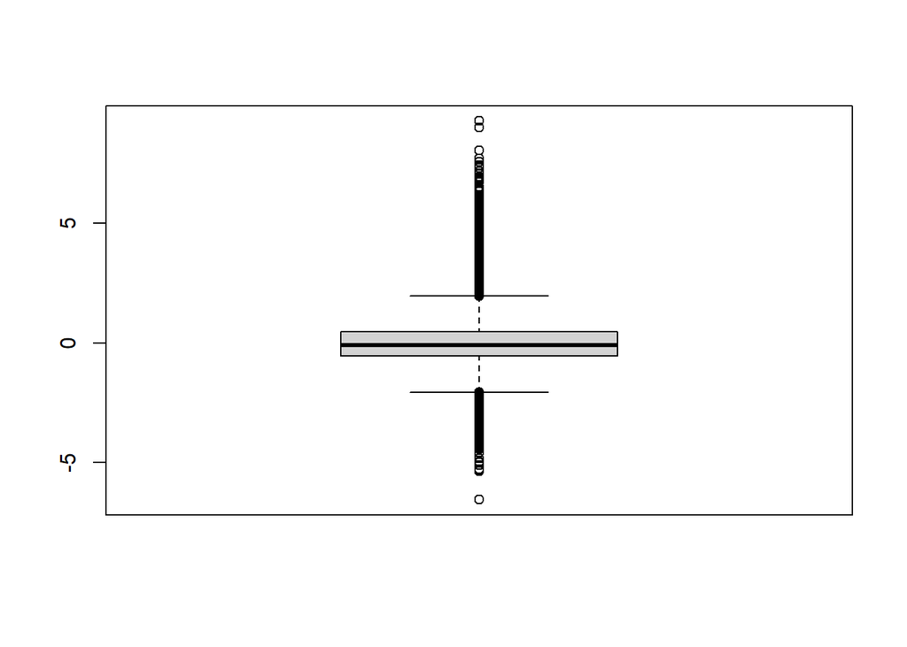

```r
residuos = rstandard(modelo_rlm)
ajustados = fitted(modelo_rlm)

boxplot(residuos)
```

Del anterior gráfico vemos que el rango intercuartílico es muy pequeño, es decir, vemos que el 50% de los datos están entre -0.44 y 0.36, sin embargo el otro 50% o es superior o inferior a estos valores. Además, apreciamos que la mediana no se sitúa en el centro de la caja (está casi pero no), presentamos una asimetría positiva, esto significa que los datos se concencetrán más en la parte inferior de la distribución, con esto no quiero decir que haya más datos, sino que el rango es más amplio (están más dispersos). Finalmente, al tener un rango intercuartílico tan pequeño tenemos muchos outliers.

Por otro lado, para analizar los residuos vamos a crear dos gráficos. El primero nos permite ver si la varianza es constante, para ello representamos los residuos vs los valores ajustados:

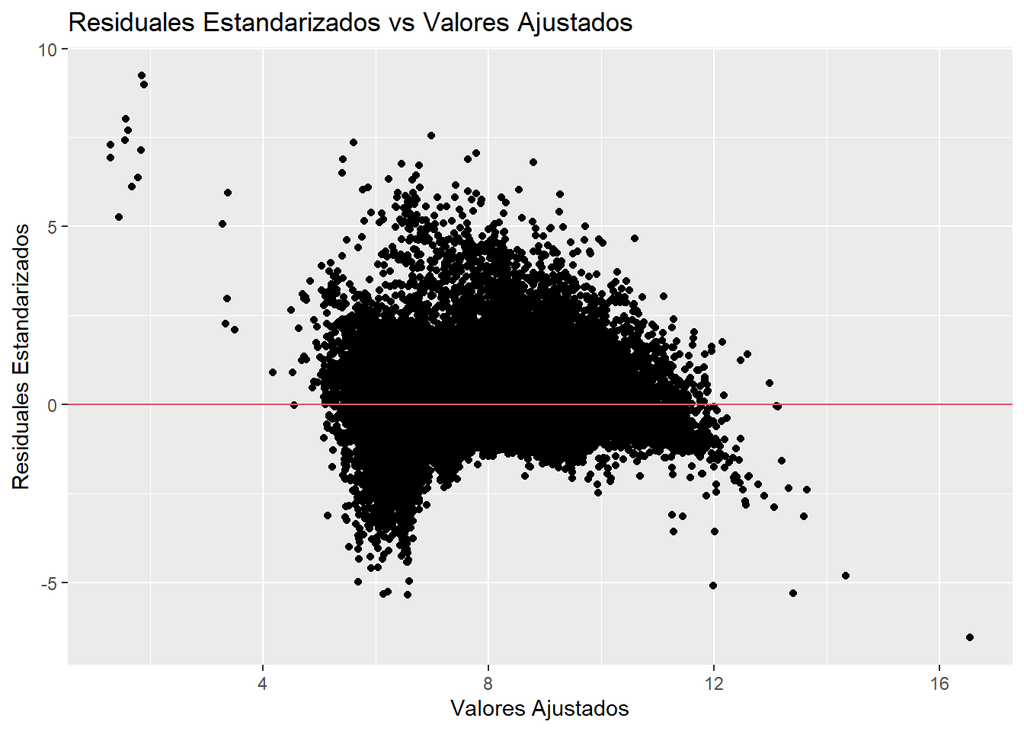

```r
qplot(x = ajustados, y = residuos, main = "Residuales Estandarizados vs Valores Ajustados", geom = c("point"), ylab = "Residuales Estandarizados", xlab = "Valores Ajustados") + geom_hline(yintercept = 0 , color = 2)
```

Del anterior gráfico observamos que el modelo se comporta por norma general bien, ya que no hay un patrón definido en los datos. Sin embargo, vemos que cuando el valor ajustado diminuye el error suele aumentar, y cuando el valor ajustado aumenta el error también aumenta.

En resumen, el modelo ajusta bien pero hay un cierto error para determinados valores, a veces el valor ajustado respecto del real es mayor y viceversa, pero estos son casos muy puntuales.

El segundo gráfico que vamos a analizar es el cuantil-cuatil, éste nos permite analizar los residuos del modelo con los valores de una variables que se distribuye normalmente:

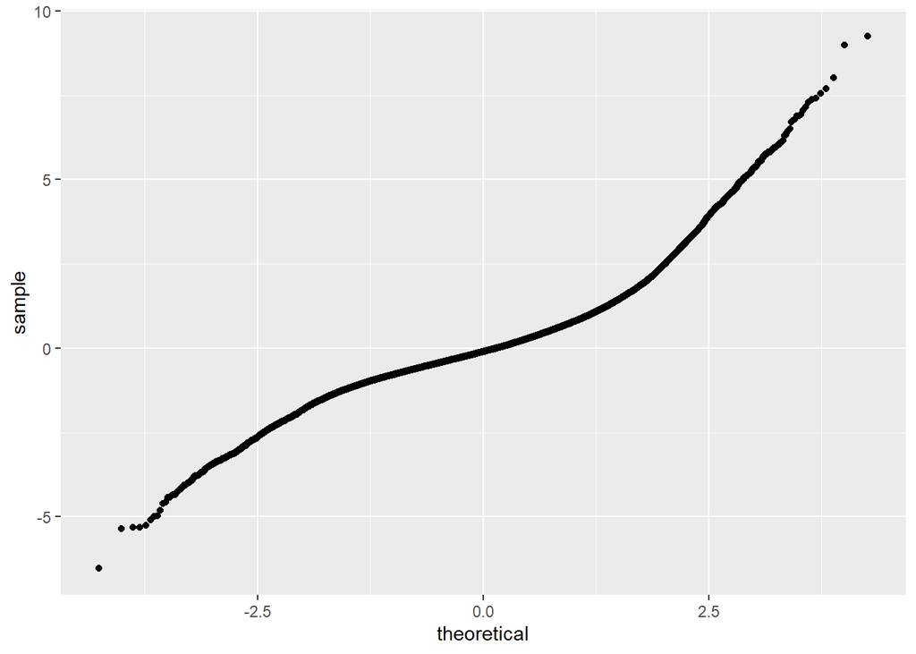

```r
ggplot(as.data.frame(residuos),aes(sample = residuos)) +  geom_qq()
```

Si los residuos siguieran una distribución normal, tendríamos todos los puntos alineados formando una recta, pero tal y como podemos ver los residuos hacen una pequeña “S”, esto nos da la idea de que cuando los valores ajustados son pequeños el modelo no ajusta del todo bien, y cuando los valores ajustados son muy grandes tampoco hace un buen ajuste.

Resumiendo, el modelo se comporta medianamente bien, lo único que hay casos especiales en los que los valores ajustados son o demasiado pequeños, o demasiado grandes.

## 3.3 Prediccion

Predecid el coste esperado para las siguientes características: Edad=24, Sexo= “F”, Estado=“S”, Dependientes=1, OtrosDepend=0, Salario=500, Jornada=“F”,HorasSemana=40,DiasSemana=5, Clasificacion=“Lento”, RiesgoSM=“TRUE” y “CosteInicio”=10000.

(Nota: Debes tener en cuenta que el valor esperado de una variable aleatoria que su logaritmo se distribuye según una normal, i.e. distribución lognormal, es exp(mu+var/2) donde mu y var son la media y la varianza de la transformación logarítmica).

A continuación vamos a predecir el valor del CosteFinal, pero antes creamos el dataframe con la prediccion, cabe destacar que en el modelo tenemos LogCosteInicio no CosteInicio, por lo tanto convertimos a escala logarítmica dicho valor:

```r
df_predict = data.frame(24, "F", "S", 1, 0, 500, "F", 40, 5, "Lento", "1", log(10000))
colnames(df_predict) = c("Edad", "Sexo", "Estado", "Dependientes", "OtrosDepend", "Salario", "Jornada", "HorasSemana", "DiasSemana", "Clasificacion", "RiesgoSM", "LogCosteInicio")
```

Una vez creado el dataframe, realizamos la predicción:

```r
prediccion_valor = predict(modelo_rlm, df_predict)
cat("El CosteFinal que se produce a partir de los datos es:", prediccion_valor, "€")
```

```
## El CosteFinal que se produce a partir de los datos es: 9.517933 €
```

Cabe destacar que el valor que obtenemos está en escala logarítmica, por lo que reconvertimos dicho valor a exponecial:

```r
prediccion_valor = exp(prediccion_valor)
cat("El CosteFinal que se produce a partir de los datos es:", prediccion_valor, "€")
```

```
## El CosteFinal que se produce a partir de los datos es: 13601.47 €
```

En este caso vemos que tendríamos un CosteFinal de 13601.47€.

# 4 Regresión logística

## 4.1 Modelo predictivo

Utilizando las mismas características como variables explicativas, ajustad un modelo predictivo basado en la regresión logística para predecir la probabilidad de que la compañía cuantifique inicialmente el coste del siniestro de forma insuficiente.

Para ello, cread una variable Deficit que indique si la valoración inicial del coste del siniestro (CosteInicio) es inferior a la indemnización finalmente pagada por la compañía (CosteFinal). La variable Deficit debe codificarse como una variable dicotómica, que toma el valor 0 cuando la valoración inicial ha sido suficiente y 1 cuando la valoración inicial ha sido insuficiente.

La variable Deficit será la variable dependiente del modelo. Analizad la calidad del modelo y las variables que son relevantes.

Lo primero que debemos de hacer para crear el modelo es la definición de la variable Deficit, es por ello que lo hacemos ahora:

```r
claimNet$Deficit[claimNet$CosteInicio >= claimNet$CosteFinal] = 0
claimNet$Deficit[claimNet$CosteInicio < claimNet$CosteFinal] = 1
claimNet$Deficit = as.factor(claimNet$Deficit)

head(claimNet)
```

```
##          Id Ocurrencia   Apertura Edad Sexo Estado Dependientes OtrosDepend
## 1 WC8285054 2002-04-09 2002-07-05   48    M      M            0           0
## 2 WC6982224 1999-01-07 1999-01-20   43    F      M            0           0
## 4 WC9775968 2005-06-22 2005-07-22   41    M      S            0           0
## 5 WC2634037 1990-08-29 1990-09-27   36    M      M            0           0
## 6 WC6828422 1999-06-21 1999-09-09   50    M      M            0           0
## 7 WC8058150 2001-07-13 2001-07-23   39    M      M            0           0
##   Salario Jornada HorasSemana DiasSemana
## 1  500.00       F        38.0          5
## 2  509.34       F        37.5          5
## 4  555.46       F        38.0          5
## 5  377.10       F        38.0          5
## 6  200.00       F        38.0          5
## 7  200.00       F        38.0          5
##                                                              Descripcion
```

[output cut: 20 more lines]

Una vez que tenemos la variable dependiente del modelo, creamos el mismo:

```r
modelo_rlg = glm(formula = Deficit ~ Edad + Sexo + Estado + Dependientes + OtrosDepend + Salario + Jornada + HorasSemana + DiasSemana + Clasificacion + RiesgoSM + LogCosteInicio, family = binomial(link=logit), data = claimNet)
```

Finalemente, para terminar con este apartado analizamos la calidad del modelo y las variables que son relevantes:

```r
summary(modelo_rlg)
```

```
##
## Call:
## glm(formula = Deficit ~ Edad + Sexo + Estado + Dependientes +
##     OtrosDepend + Salario + Jornada + HorasSemana + DiasSemana +
##     Clasificacion + RiesgoSM + LogCosteInicio, family = binomial(link = logit),
##     data = claimNet)
##
## Deviance Residuals:
##     Min       1Q   Median       3Q      Max
## -5.4153  -1.1179   0.6951   0.9877   2.3301
##
## Coefficients:
##                          Estimate Std. Error z value Pr(>|z|)
## (Intercept)             3.876e+00  1.368e-01  28.328  < 2e-16 ***
## Edad                    1.122e-02  9.980e-04  11.241  < 2e-16 ***
## SexoM                  -3.755e-01  2.436e-02 -15.414  < 2e-16 ***
## EstadoS                -6.871e-02  2.397e-02  -2.866  0.00415 **
## Dependientes            1.090e-01  1.999e-02   5.450 5.03e-08 ***
## OtrosDepend             1.719e-01  9.432e-02   1.822  0.06841 .
## Salario                 2.272e-03  5.416e-05  41.945  < 2e-16 ***
## JornadaP                1.821e-01  4.528e-02   4.022 5.76e-05 ***
## HorasSemana            -6.938e-04  8.648e-04  -0.802  0.42240
## DiasSemana             -1.535e-01  2.448e-02  -6.270 3.61e-10 ***
## ClasificacionRápido     9.624e-02  2.449e-02   3.929 8.53e-05 ***
## ClasificacionLento      5.029e-02  2.564e-02   1.961  0.04986 *
## ClasificacionMuy lento -4.382e-02  3.821e-02  -1.147  0.25152
## RiesgoSM1               7.214e-02  1.475e-01   0.489  0.62480
## LogCosteInicio         -4.902e-01  7.504e-03 -65.332  < 2e-16 ***
## ---
## Signif. codes:  0 '***' 0.001 '**' 0.01 '*' 0.05 '.' 0.1 ' ' 1
##
## (Dispersion parameter for binomial family taken to be 1)
##
##     Null deviance: 66399  on 48674  degrees of freedom
## Residual deviance: 60617  on 48660  degrees of freedom
## AIC: 60647
##
## Number of Fisher Scoring iterations: 4
```

Para poder medir cómo de bueno es el modelo, nos tenemos que fijar en la devianza, si la devianza residual es menor que la devianza nula, entonces hemos conseguido mejorar el modelo. Podemos obtener un valor númerico si hacemos (Null deviance - Residual deviance) / Null deviance:

```r
cat("Calidad del modelo de regresión logística es de:", round((modelo_rlg$null.deviance - modelo_rlg$deviance) / modelo_rlg$null.deviance * 100, 2), "%")
```

```
## Calidad del modelo de regresión logística es de: 8.71 %
```

Como podemos observar la calidad del modelo no es que sea muy buena, si fuera un bueno modelo su valor estaría cercano al 100%, sin embargo, está más cerca del 0 que del 100 ya que la devianza residual es muy grande, por lo que no es un buen modelo.

El otro aspecto a analizar son las variables relevantes, pero como esto es lo que se pide en el siguiente apartado, es allí dónde lo vamos a hacer.

## 4.2 Interpretación

Interpretad el modelo ajustado. Concretamente, explicad la contribución de las variables explicativas con coeficiente estadísticamente significativo para predecir si la valoración inicial es insuficiente para cubrir el coste del siniestro.

Las variables estadísticamente significativas son aquellas cuyo Pr(>|z|) < 0.05:

- Edad: su coeficiente es positivo, por lo que a medida que aumenta la edad, la probabilidad de lo que estamos prediciendo (Deficit) aumenta.
- Sexo: su coeficiente es negativo en este caso para ver el impacto tenemos que analizar su OR, es decir, si es un factor de riesgo o de protección. Tal y como podemos observar, si el sexo es masculino es un factor de protección respecto al sexo femenino, es decir, es menos probable que haya un deficit se eres hombre que si eres mujer:

```r
exp(coefficients(modelo_rlg))
```

```
##            (Intercept)                   Edad                  SexoM
##             48.2144383              1.0112821              0.6869197
##                EstadoS           Dependientes            OtrosDepend
##              0.9335960              1.1151210              1.1875296
##                Salario               JornadaP            HorasSemana
##              1.0022742              1.1997821              0.9993064
##             DiasSemana    ClasificacionRápido     ClasificacionLento
##              0.8577338              1.1010204              1.0515741
## ClasificacionMuy lento              RiesgoSM1         LogCosteInicio
##              0.9571279              1.0748035              0.6124767
```

- Estado: sucede parecido al Sexo, tenemos un coeficiente negativo y a la vista de los OR, EstadoS su OR es menor que 1, por lo tanto, tenemos un coeficiente de protección, es decir, si el Estado es soltero es menos probable que haya déficit que si estás casado.
- Dependientes: su coeficiente es positivo, por lo que a medida que aumenta dicha variable también aumenta la probabilidad que suceda el déficit.
- Salario: tiene un coeficiente positivo, por lo tanto a medida que aumenta el salario también aumenta la probabilidad de que haya un déficit.
- Jornada: tiene un coeficiente positivo, por lo que aumenta el riesgo de que haya un déficit.
- DiasSemana: tiene un coeficiente negativo, por lo que es un factor de protección, a medida que aumenta dicha variable menos riesgo hay de que haya un déficit.
- Clasificacion: tanto si la clasifación es rápida como lenta es un factor de riesgo, ya que supone un aumento en la probabilidad de que haya un déficit.
- LogCosteInicio: tiene un coeficiente negativo, analizando su OR vemos que es un factor de protección, ya que al aumentar dicha variable reduce la probabilidad de déficit.

## 4.3 Matriz de confusión

A continuación analizad la precisión del modelo, comparando la predicción del modelo sobre los mismos datos del conjunto de datos. Asumiremos que la predicción del modelo es 1 (valoración inicial del coste insuficiente) si la probabilidad del modelo de regresión logística es superior o igual a 0.5 y 0 en caso contrario. Analizad la matriz de confusión y las medidas de ‘sensitivity’ y ‘specificity’.

Nota: Tomad como categoría de interés que haya déficit en la valoración inicial del coste. Por tanto, déficit igual a 1 será el caso positivo en la matriz de confusión y 0 el caso negativo.

Lo primero de todo es calcular las predicciones del modelo:

```r
predicciones = predict(object =  modelo_rlg, newdata = claimNet[, c(
  "Edad",
  "Sexo",
  "Estado",
  "Dependientes",
  "OtrosDepend",
  "Salario",
  "Jornada",
  "HorasSemana",
  "DiasSemana",
  "Clasificacion",
  "RiesgoSM",
  "LogCosteInicio"
)])
```

Aunque tengamos las predicciones en sí, tienes que estar dicotomizadas, es por ello que si la predicción es >= 0.5 toma valor 1 o 0 en caso contrario:

```r
predicciones[predicciones >= 0.5] = 1
predicciones[predicciones < 0.5] = 0
```

Ahora ya podemos construir la matriz de confusión, pero antes establecemos la variable objetivo como numérica, al hacer as.integer(factor) suma uno, por lo que restamos dicho valor:

```r
valores_originales = as.integer(claimNet$Deficit) - 1
```

Creamos la matriz de confusión:

```r
matriz_confusion = table(valores_originales, predicciones)
matriz_confusion
```

```
##                   predicciones
## valores_originales     0     1
##                  0 14536  6185
##                  1 12732 15222
```

Cabe mencionar que “1” es caso positivo (hay déficit) y “0” es caso negativo.

Una vez calculada la matriz de confusión podemos calcular las medias que nos indican:

- Sensibilidad, es la tasa de verdaderos positivos, la proporción de los clasificados correctamente entre todos los que han dado positivo:

```r
sensibilidad = matriz_confusion[2,2] / (matriz_confusion[2,2] + matriz_confusion[2,1])
cat("La sensibilidad es igual a", sensibilidad)
```

```
## La sensibilidad es igual a 0.5445375
```

Como vemos la sensibilidad no es del todo buena, ya que si fuera 1 indicaría que todo lo ha clasificado correctamente, al ser 0.54 por norma general lo clasifica bien, pero este modelo no es muy bueno al predecir positivos.

- Especificidad, es la tasa de verdaderos negativos, la proporción de casos correctamente clasificados entre todos los que han dado negativo:

```r
especificidad = matriz_confusion[1,1] / (matriz_confusion[1,1] + matriz_confusion[1,2])
cat("La especificidad es igual a", especificidad)
```

```
## La especificidad es igual a 0.7015105
```

En este caso, vemos que la especificidad es algo mejor, está más próxima a uno por lo que el modelo es capaz de predecir mejor cuando un caso es negativo que cuando es positivo.

## 4.4 Predicción

¿Con que probabilidad la valoración inicial del siniestro será insuficiente para un hombre de 20 años de edad, soltero, sin hijos ni otros dependientes, con un salario semanal de 300 EUR, jornada partida, con 30 horas semanales y cinco días a la semana, una clasificación del tiempo hasta la apertura del siniestro de “Muy lento”, una baja que no es por depresión y una valoración inicial de 10000EUR?

A continuación vamos a predecir el valor de Deficit, pero antes creamos el dataframe con la prediccion, cabe destacar que en el modelo tenemos LogCosteInicio no CosteInicio, por lo tanto convertimos a escala logarítmica dicho valor:

```r
df_predict = data.frame(20, "M", "S", 0, 0, 300, "P", 30, 5, "Muy lento", "0", log(10000))
colnames(df_predict) = c("Edad", "Sexo", "Estado", "Dependientes", "OtrosDepend", "Salario", "Jornada", "HorasSemana", "DiasSemana", "Clasificacion", "RiesgoSM", "LogCosteInicio")
```

Una vez creado el dataframe, realizamos la predicción:

```r
prediccion_valor = predict(modelo_rlg, df_predict)

if (prediccion_valor >= 0.5) cat("El Deficit que obtenemos a partir de los datos es: 1")
if (prediccion_valor < 0.5) cat("El Deficit que obtenemos a partir de los datos es: 0")
```

```
## El Deficit que obtenemos a partir de los datos es: 0
```

De la ejecución anterior, observamos que para ese tipo de cliente no hay riesgo de déficit.

# 5 Análisis de la varianza (ANOVA) de un factor

Vamos a realizar un ANOVA para contrastar si existen diferencias en la variable CosteFinal en escala logarítmica en función de la clasificación del siniestro en relación al tiempo transcurrido hasta la apertura. Seguid los pasos que se indican.

## 5.1 Hipótesis nula y alternativa

Escribid la hipótesis nula y la alternativa.

En un análisis de ANOVA partimos de la hipótesis nula que no hay diferencia de la variabilidad entre los diferentes grupos, y la hipóstesis alternativa es que al menos hay una diferencia. Esto lo podemos representar de la siguiente forma:

- H0 (hipótesis nula): variabilidad_MuyRapido = variabilidad_Rapido = variabilidad_Lento = variabilidad_MuyLento
- H1 (hipótesis alternativa): variablidad_Grupo_I != variabilidad_Grupo_J (donde i y j son los diferentes grupos, muy rápido, rápido, lento, muy lento. Al menos tiene que haber una diferencia entre grupos)

Otra forma de representarlo de forma general es:

- H0 (hipótesis nula): alfa_i = alfa_j
- H1 (hipótesis alternativa): alfa_i != alfa_j para algún i != j

## 5.2 Modelo

Calculad el análisis de varianza, usando la función aov o lm. Interpretad el resultado del análisis, teniendo en cuenta los valores: Sum Sq, Mean SQ, F y Pr (> F).

Lo primero de todo es crear el modelo, nos indican que tenemos que analizar el CosteFinal en escala logarítmica en función de la clasificación del siniestro:

```r
modelo_anova = aov(formula = LogCosteFinal ~ Clasificacion, data = claimNet)

summary(modelo_anova)
```

```
##                  Df Sum Sq Mean Sq F value Pr(>F)
## Clasificacion     3    190   63.29   27.09 <2e-16 ***
## Residuals     48671 113707    2.34
## ---
## Signif. codes:  0 '***' 0.001 '**' 0.01 '*' 0.05 '.' 0.1 ' ' 1
```

De la anterior ejecución, vemos que Pr(>F) es mucho menor que el nivel de significancia, es decir, Pr(>F) < 0.05, por lo tanto podemos rechazar la hipótesis nula en favor de la alternativa, esto significa, que al menos hay una diferencia entre la variabilidad de los grupos según la Clasificación de los siniestros.

Al rechazar la hipótesis nula, estamos diciendo que la clasificación de los siniestros en relación al tiempo afecta al coste final de la indemnización.

Otra cosa a destacar, es que ANOVA nos hace una estimación de la varianza del error, en nuestro caso dicha estimación es de 2.34.

## 5.3 Efectos de los niveles del factor

Calculad la variabilidad explicada por la variable Clasificacion sobre la variable CosteFinal mediante la métrica eta squared. Interpretad los resultados.

```r
etaSquared(modelo_anova)
```

```
##                    eta.sq eta.sq.part
## Clasificacion 0.001667102 0.001667102
```

El eta squared para la variable clasificación sobre la variable CosteFinal es de 0.0017, como podemos apreciar sale una variabilidad baja, por lo que el CosteFinal no depende de clasificación.

Esta medida lo que nos indica es la variabilidad explicada por el atributo Clasificación, es decir, en nuestro caso el 0.17% de la variabilidad de CosteFinal es explicado por este atributo, como vemos es muy poco, prácticamente insignificante.

Cabe destacar que este resultado es el mismo si hacemos el Sum Sq de Clasificacion / (Sum Sq de Clasificacion + Sum Sq de Residuals).

## 5.4 Contraste dos-a-dos

Como los factores han resultado significativos hay que hacer los contrastes de las comparaciones múltiples. Se puede utilizar la prueba de Tukey-Kramer que compara dos-a-dos las diferentes categorías de la variable.

(Nota: por ejemplo, con la función HSD.test() del paquete agricolae).

Hacemos uso del test de Tukey-Kramer para comparar dos a dos los diferentes grupos:

```r
HSD.test(modelo_anova, "Clasificacion", console = TRUE)
```

```
##
## Study: modelo_anova ~ "Clasificacion"
##
## HSD Test for LogCosteFinal
##
## Mean Square Error:  2.336238
##
## Clasificacion,  means
##
##            LogCosteFinal      std     r      Min      Max
## Lento           8.014673 1.542670 13589 2.334284 14.16842
## Muy lento       7.996111 1.634199  4060 3.234919 13.52911
## Muy rápido      7.917190 1.503789 14789 1.746615 13.93241
## Rápido          8.072725 1.511404 16237 1.937128 14.26693
##
## Alpha: 0.05 ; DF Error: 48671
## Critical Value of Studentized Range: 3.63316
##
## Groups according to probability of means differences and alpha level( 0.05 )
##
## Treatments with the same letter are not significantly different.
##
##            LogCosteFinal groups
## Rápido          8.072725      a
## Lento           8.014673      b
## Muy lento       7.996111      b
## Muy rápido      7.917190      c
```

De la anterior ejecución observamos que aunque hay cuatro niveles de clasificación, el test los ha agrupado en 3 grupos:

- Un grupo cuando la clasificación es “Rápido”.
- Otro grupo cuando la clasificación es “Lento” y “Muy lento”.
- El último grupo cuando la clasificación es “Muy rápido”.

Al generarnos 3 grupos, vemos que realmente sí que había diferencias significativas entre varios niveles:

- El nivel “Rápido” presenta una diferencia de medias respecto a los niveles (“Lento”, “Muy lento”) y “Muy rápido”. Además, este grupo es que provoca un mayor Logcostefinal.
- Los niveles “Lento” y “Muy lento” presentan una diferencia de medias similar y por eso están agrupados, sin embargo, ésta es diferente del nivel “Rápido” y del nivel “Muy rápido”. El LogCosteFinal que obtenemos respecto a este grupo es algo menor que en el anterior caso.
- El nivel “Muy rápido” tiene una diferencia de medias diferente al nivel “Rápido” y a los niveles (“Lento”, “Muy lento”). Y el LogCosteFinal obtenido con este grupo es el menor de todos, por lo que si la clasificación es “Muy rápido” el LogCosteFinal y en consecuencia CosteFinal va a ser menor.

## 5.5 Adecuación del modelo

Mostrad la adecuación del modelo ANOVA. Se pide lo siguiente:

- Análisis visual de normalidad de los residuos. Podéis usar la función plot sobre el modelo ANOVA calculado.
- Análisis visual de homocedasticidad de los residuos. Podéis usar plot sobre el modelo ANOVA calculado.
- Contraste de normalidad y homocedasticidad.

### 5.5.1 Normalidad de los residuos

El análisis visual de la normalidad de los residuos se puede hacer a partir del gráfico Normal Q-Q. Mostrad e interpretad este gráfico.

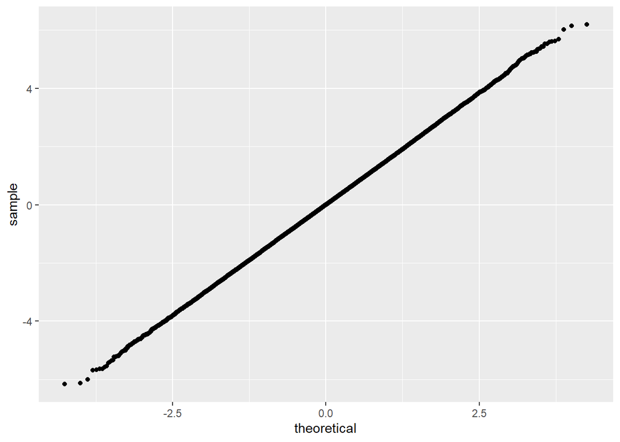

```r
residuos = residuals(modelo_anova)
ajustados = fitted(modelo_anova)

ggplot(as.data.frame(residuos),aes(sample = residuos)) +  geom_qq()
```

En este caso vemos que los residuos sí que siguen más o menos una distribución normal casi perfecta, solo para valores muy pequeños o muy altos hay una ligera desviación, pero en su gran mayoría se ajustan muy bien a la distribución normal.

### 5.5.2 Homocedasticidad de los residuos

El gráfico “Residuals vs Fitted” proporciona información sobre la homcedasticidad de los residuos. Mostrad e interpretad este gráfico.

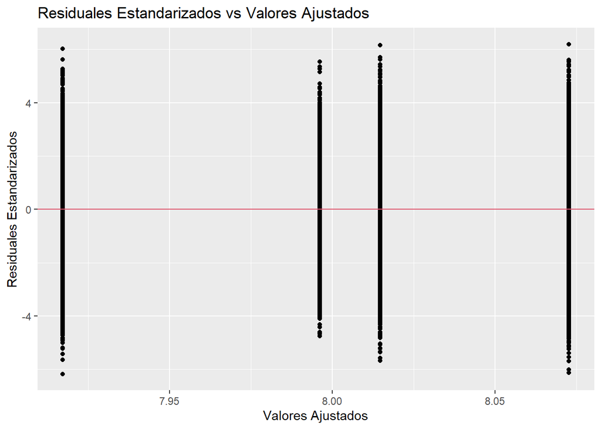

```r
qplot(x = ajustados, y = residuos, main = "Residuales Estandarizados vs Valores Ajustados", geom = c("point"), ylab = "Residuales Estandarizados", xlab = "Valores Ajustados") + geom_hline(yintercept = 0 , color = 2)
```

Tenemos cuatro tiras una por cada nivel que hay de la variable Clasificación, es decir, una tira para “Muy rápido”, otra para “Rápido”, otra para “Lento” y otra para “Muy lento”. Además, los puntos dentro de cada grupo no están distribuidos de forma homógena no se puede garantizar que estemos en un caso de homogeneidad de varianza, pero para comprobarlo aplicaremos el test de Bartlett en el siguiente punto.

### 5.5.3 Contraste de normalidad

Comprobar el supuesto de normalidad de los residuos con las purebas estadísticas de Shapiro-Wilk o Lilliefors, entre otros.

Realizamos la prueba de Lilliefors:

```r
lillie.test(residuos)
```

```
##
##  Lilliefors (Kolmogorov-Smirnov) normality test
##
## data:  residuos
## D = 0.0018258, p-value = 0.959
```

Como el pvalor es mayor que el nivel de significancia (0.05), mantenemos la hipótesis nula, siendo ésta que los datos siguen una distribución normal.

### 5.5.4 Contraste de homocedasticidad

Comprobar el supuesto de homocedasticidad se puede comprobar a partir de la prueba de Bartleet.

Aplicamos la prueba de Bartlett:

```r
bartlett.test(formula = LogCosteFinal ~ Clasificacion, data = claimNet)
```

```
##
##  Bartlett test of homogeneity of variances
##
## data:  LogCosteFinal by Clasificacion
## Bartlett's K-squared = 52.145, df = 3, p-value = 2.789e-11
```

Vemos que el pvalor es menor que alfa (0.05), en este caso rechazamos la hipótesis nula a favor de la alternativa, es decir, estamos en una caso de heterogeneidad de varianzas.

# 6 ANOVA multifactorial

A continuación, se desea evaluar el efecto sobre CosteFinal en escala logarítmica según Sexo combinado con el factor RiesgoSM. Seguid los pasos que se indican a continuación.

## 6.1 Análisis de los efectos principales y posibles interacciones

Dibujad en un gráfico la variable CosteFinal en escala logarítmica en función de Sexo y en función de RiesgoSM. El gráfico debe permitir evaluar si hay interacción entre los dos factores. Por ello, se recomienda seguir estos pasos:

1. Agrupad el conjunto de datos por Sexo y por RiesgoSM. Calculad el número de casos disponibles de cada combinación de factores.
2. Calculad la media de coste (en log) para cada grupo.
3. Mostrad en un gráfico el valor medio de la variable CosteFinal en escala logarítmica para cada factor.
4. Interpretad el resultado sobre si sólo hay efectos principales o hay interacción entre los factores. Si hay interacción, explicad cómo se observa esta interacción en el gráfico.

Lo primero que vamos a hacer es crear el dataframe con la información necesaria, respecto a la variable Sexo solo tenemos dos posible valores (“F” o “M”) y respecto al RiesgoSM (“1” o “0” ), por lo tanto, vamos a tener 4 combinaciones posibles: F-0, F-1, M-0 y M-1. Creamos el dataframe con la media del CosteFinal en escala logarítmica para cada grupo:

```r
df_efectos_principales = data.frame(c("F", "F", "M", "M"), c("0", "1", "0", "1"))
colnames(df_efectos_principales) = c("Sexo", "RiesgoSM")
df_efectos_principales$Sexo = as.factor(df_efectos_principales$Sexo)
df_efectos_principales$RiesgoSM = as.factor(df_efectos_principales$RiesgoSM)

# Calculamos la media para cada grupo
vCosteFinal_F0 = mean(claimNet[claimNet$Sexo == "F" & claimNet$RiesgoSM == "0", "LogCosteFinal"])
vCosteFinal_F1 = mean(claimNet[claimNet$Sexo == "F" & claimNet$RiesgoSM == "1", "LogCosteFinal"])
vCosteFinal_M0 = mean(claimNet[claimNet$Sexo == "M" & claimNet$RiesgoSM == "0", "LogCosteFinal"])
vCosteFinal_M1 = mean(claimNet[claimNet$Sexo == "M" & claimNet$RiesgoSM == "1", "LogCosteFinal"])

# Creamos la nueva variable en el dataframe
df_efectos_principales$Mean_LogCosteFinal = c(vCosteFinal_F0, vCosteFinal_F1, vCosteFinal_M0, vCosteFinal_M1)

# visualizamos el dataframe creado
df_efectos_principales
```

```
##   Sexo RiesgoSM Mean_LogCosteFinal
## 1    F        0           8.271703
## 2    F        1          10.189007
## 3    M        0           7.910462
## 4    M        1           9.959641
```

Una vez que tenemos el dataframe que nos interesa, creamos el gráfico de interacción:

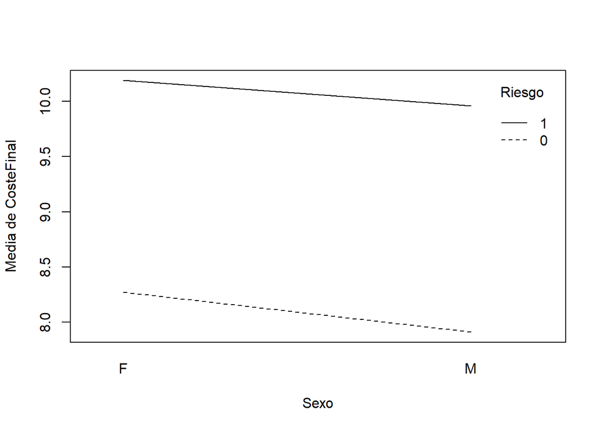

```r
interaction.plot(df_efectos_principales$Sexo,
                 df_efectos_principales$RiesgoSM,
                 df_efectos_principales$Mean_LogCosteFinal,
                 xlab = "Sexo",
                 ylab = "Media de CosteFinal",
                 trace.label = "Riesgo")
```

En el eje X tenemos la variable Sexo, la cual tiene los niveles: “F” - Femenino y “M” - Masculino. En el eje Y tenemos la media del CosteFinal. Además, tenemos 4 casos (F0, F1, M0, M1) están unidos por el factor Riesgo.

Una vez hecha esta aclaración, podemos observar que las líenas son paralelas, no se cortan ni se van a cortar, por lo que no hay interacción entre las variables.

Analizando el gráfico anterior, observamos que si el riesgo es 1, el CosteFinal es mucho mayor que si el riesgo fuera 0. Además, si el sexo es femenino suele suponer un CosteFinal mayor que si el sexo es masculino.

A continuación, vamos a realizar el cálculo del modelo ANOVA y se va a analizar.

## 6.2 Cálculo del modelo

- Calculad el modelo incluyendo la interacción entre los factores.
- Medid el efecto de los factores sobre la variabilidad explicada del Coste final (en escala logarítmica).
- Análizad dos-a-dos las diferencias de medias entre los distintos factores.
- Adecuación del modelo. Realizar análisis visual de normalidad y homocedasticidad.

### 6.2.1 Modelo

Lo primero de todo es crear el modelo de las variables LogCosteFinal, el Sexo, el RiesgoSM y la interacción de éstos. Aunque en el anterior apartado hemos visto que no hay interacción, tal y como se indica en el enunciado creamos el modelo con la interacción:

```r
modelo_anova = aov(formula = LogCosteFinal ~ Sexo + RiesgoSM + Sexo:RiesgoSM, data = claimNet)

summary(modelo_anova)
```

```
##                  Df Sum Sq Mean Sq F value Pr(>F)
## Sexo              1   1174  1173.9 510.771 <2e-16 ***
## RiesgoSM          1    858   857.9 373.276 <2e-16 ***
## Sexo:RiesgoSM     1      1     0.9   0.386  0.534
## Residuals     48671 111864     2.3
## ---
## Signif. codes:  0 '***' 0.001 '**' 0.01 '*' 0.05 '.' 0.1 ' ' 1
```

Por otro lado, aquellos factores en los que Pr(>F) < 0.05, rechazamos la hipótesis nula en favor de la alternativa, es decir, que al menos hay una diferencia de la variabilidad de los grupos tanto para Sexo como para RiesgoSM. Esto significa que el CosteFinal sí que se ve afectado por el Sexo y el RiesgoSM.

### 6.2.2 Efectos de los niveles del factor

Para medir el efecto de los niveles, hacemos uso de etaSquared:

```r
etaSquared(modelo_anova)
```

```
##                     eta.sq  eta.sq.part
## Sexo          9.865646e-03 9.945024e-03
## RiesgoSM      7.532493e-03 7.611000e-03
## Sexo:RiesgoSM 7.791747e-06 7.933273e-06
```

El eta squared es una medida que nos indica la variabilidad explicada por cada uno de los factores, es decir, por ejemplo la variable Sexo explica el 0.9% de la variabilidad de LogCosteFinal, como vemos es muy poco siendo esta variable la que tiene un mayor eta squared. Por lo tanto, vemos que el LogCosteFinal no depende mucho de estas variables.

### 6.2.3 Contraste dos-a-dos

Como la variable Sexo y RiesgoSM son significativas, es decir, hay una diferencia de la variabilidad en sus grupos, tenemos que hacer uso del test de Tukey para saber cómo se distribuyen dichos grupos.

Por lo tanto, lo primero es aplicar dicho test para la variable Sexo:

```r
HSD.test(modelo_anova, "Sexo", console = TRUE)
```

```
##
## Study: modelo_anova ~ "Sexo"
##
## HSD Test for LogCosteFinal
##
## Mean Square Error:  2.298374
##
## Sexo,  means
##
##   LogCosteFinal      std     r      Min      Max
## F      8.286010 1.418945 11257 3.401110 14.26693
## M      7.917691 1.551428 37418 1.746615 14.16842
##
## Alpha: 0.05 ; DF Error: 48671
## Critical Value of Studentized Range: 2.771808
##
## Groups according to probability of means differences and alpha level( 0.05 )
##
## Treatments with the same letter are not significantly different.
##
##   LogCosteFinal groups
## F      8.286010      a
## M      7.917691      b
```

En este caso vemos que que tenemos dos grupos, uno relativo al sexo cuando éste es femenino y otro para masculino.

Realizamos el mismo proceso para analizar el RiesgoSM:

```r
HSD.test(modelo_anova, "RiesgoSM", console = TRUE)
```

```
##
## Study: modelo_anova ~ "RiesgoSM"
##
## HSD Test for LogCosteFinal
##
## Mean Square Error:  2.298374
##
## RiesgoSM,  means
##
##   LogCosteFinal      std     r      Min      Max
## 0      7.993752 1.525308 48459 1.746615 14.26693
## 1     10.048839 1.073968   216 7.355029 13.45198
##
## Alpha: 0.05 ; DF Error: 48671
## Critical Value of Studentized Range: 2.771808
##
## Groups according to probability of means differences and alpha level( 0.05 )
##
## Treatments with the same letter are not significantly different.
##
##   LogCosteFinal groups
## 1     10.048839      a
## 0      7.993752      b
```

Al igual que antes tenemos dos grupos, uno cuando hay riesgo de padecer enfermedad mental y otro cuando no.

Para termnar con este apartado, vamos a analizar las diferencias dos-a-dos para la interacción de Sexo y RiesgoSM (aunque haya salido que no es significativa). Primero tenemos que quedar con la interacción:

```r
interaccion = with(claimNet, interaction(claimNet$Sexo, claimNet$RiesgoSM))
```

Ahora, volvemos a crear el modelo pero solamente para la interacción:

```r
modelo_anova_interaccion = aov(formula = LogCosteFinal ~ interaccion, data = claimNet)
```

Finalmente, ejecutamos el HSD test para identificar los grupos:

```r
HSD.test(modelo_anova_interaccion, "interaccion", console = TRUE)
```

```
##
## Study: modelo_anova_interaccion ~ "interaccion"
##
## HSD Test for LogCosteFinal
##
## Mean Square Error:  2.298374
##
## interaccion,  means
##
##     LogCosteFinal       std     r      Min      Max
## F.0      8.271703 1.4123165 11173 3.401110 14.26693
## F.1     10.189007 0.9333191    84 7.355029 11.92483
## M.0      7.910462 1.5479010 37286 1.746615 14.16842
## M.1      9.959641 1.1491186   132 7.363679 13.45198
##
## Alpha: 0.05 ; DF Error: 48671
## Critical Value of Studentized Range: 3.63316
##
## Groups according to probability of means differences and alpha level( 0.05 )
##
## Treatments with the same letter are not significantly different.
##
##     LogCosteFinal groups
## F.1     10.189007      a
## M.1      9.959641      a
## F.0      8.271703      b
## M.0      7.910462      c
```

Vemos que en este caso hay 3 grupos aunque tengamos 4 niveles:

- El grupo A, que incluye F1 y M1, es decir, da igual si eres hombre o mujer, si padeces una enfermedad mental el CosteFinal va a ser más elevado que si no la padeces.
- El grupo B, sexo femenino y sin enfermedad mental.
- El grupo C, sexo masculino y sin enfermedad mental.

En resumen, vemos que lo que más afecta al CosteFinal es si padeces una enfermedad mental, y luego entre si eres hombre o mujer, estas últimas afectan más que los hombres.

### 6.2.4 Adecuación del modelo

En este apartado nos indican realizar el análisis visual de normalidad y homocedasticidad.

#### 6.2.4.1 Normalidad de la residuos

El análisis visual de la normalidad de los residuos se puede hacer a partir del gráfico Normal Q-Q. Mostrad e interpretad este gráfico:

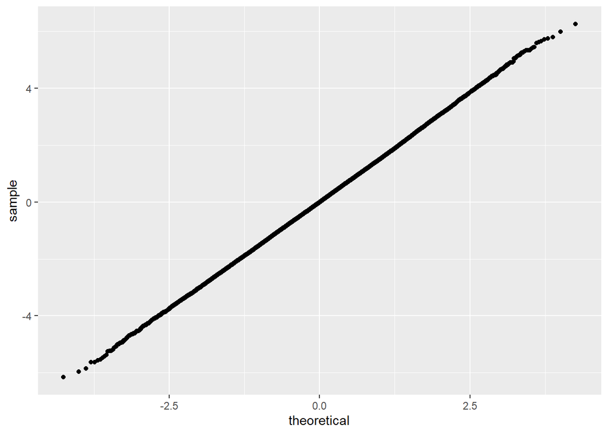

```r
residuos = residuals(modelo_anova)
ajustados = fitted(modelo_anova)

ggplot(as.data.frame(residuos),aes(sample = residuos)) +  geom_qq()
```

Respecto a este modelo, vemos que los residuos sí que siguen más o menos una distribución normal, solo para valores muy altos o muy bajos hay un ligerísima desviación, pero podemos apreciar que forma una recta casi perfecta, por lo tanto, seguimos una distribución normal.

#### 6.2.4.2 Homocedasticidad de los residuos

El gráfico “Residuals vs Fitted” proporciona información sobre la homcedasticidad de los residuos. Mostrad e interpretad este gráfico:

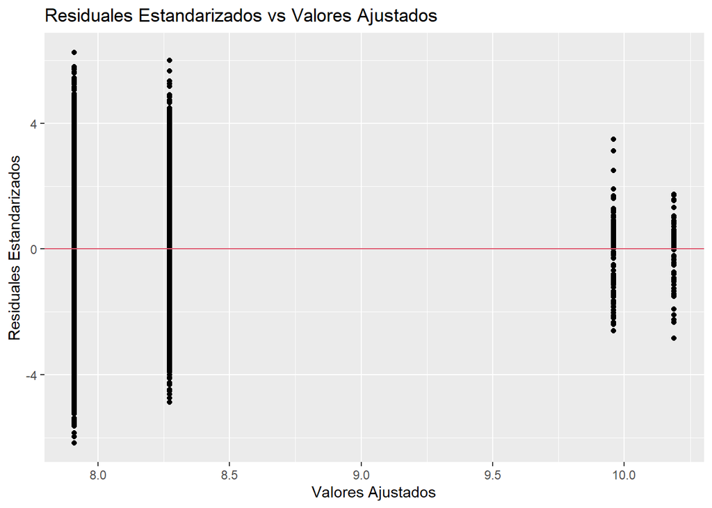

```r
qplot(x = ajustados, y = residuos, main = "Residuales Estandarizados vs Valores Ajustados", geom = c("point"), ylab = "Residuales Estandarizados", xlab = "Valores Ajustados") + geom_hline(yintercept = 0 , color = 2)
```

En este caso tenemos 4 grupos, si el RiesgoSM es 1 o 0 y si el Sexo es F o M, vemos que dentro de cada grupo no están distribuidos los puntos de forma homogénea, por lo que no podemos garantizar la homogeneidad de las varianzas, es decir, estamos en un caso de heterogeneidad de varianzas.

## 6.3 Interpretación de los resultados

Respecto a este modelo ANOVA, hemos visto que no hay interacción entre los factores, es decir, no existe ninguna relación entre Sexo y RiesgoSM. Sin embargo, analizando los efectos principales, hemos visto que si se padece una enfermedad mental el CosteFinal va a ser mayor que ni no se padece, también si el sexo es femenino tiende a suponer un mayor CosteFinal que si el sexo es masculino.

# 7 Conclusiones

Resumid las conclusiones principales del análisis. Para ello, podéis resumir las conclusiones de cada uno de los apartados.

Respecto a la primera parte de la práctica “Estadística inferencial”, nos hemos planetado la pregunta, ¿podemos aceptar que la indemnización a las mujeres supera en más de 1000€ la de hombres? Realizando el contraste de hipótesis correspondiente (contraste de dos muestras independientes sobre la media con varianzas desconocidas y heterogéneas), nos ha dado un pvalor < 2.2e-16 con un nivel de confianza del 95%, por lo que a la vista del contraste, hemos podido rechazar la hipótesis nula en favor de la alternativa, siendo ésta que hay una diferencia en la idemnización de las mujeres respecto a la de los hombres, ya que de media es superada por 1000€.

La siguiente parte de la práctica nos hemos planteado la predicción del CosteFinal dependiendo de variables como Edad, Sexo, Estado, Dependientes, OtrosDepend, Salario, Jornada, HorasSemana, DiasSemana, Clasificacion, RiesgoSM, CosteInicio. Para ello, hemos creado un modelo de regresión lienal cuyo R2 era 0.733 (73.3% de la variabilidad es explicada por el modelo), es decir, no es el mejor modelo pero ajusta bien los datos.

Aunque se han incluido muchas variables independientes en el modelo, realmente significativas son: Edad, Sexo, Estado, Dependientes, Salario, Jornada, DiasSemana, Clasificación, RiesgoSM y LogCosteInicio.

Otra problema que nos hemos planteado era el predecir el Deficit, es decir, si la valoración del coste del siniestro (CosteInicio) es inferior a la indemnización pagada por la compañía (CosteFinal). Para ello, se ha planteado un modelo de regresión logística, siendo 1 si hay déficit o 0 en caso contrario. Como variables independientes de este modelo vamos a tener todas las que teníamos en el modelo anterior. Este modelo nos ha dado una calidad del 8.71%, por lo que no es nada bueno ya que está más cerca del 0% que del 100%.

En este caso las variables independientes significativas para el modelo han sido: Edad, Sexo, Estado, Dependientes, Salario, Jornada, DiasSemana, Clasificación, LogCosteInicio.

Al calcular la matriz de confusión, hemos podido analizar cómo clasificaba los datos. Respecto a la medida sensibilidad de la matriz de confusión, es decir, la proporción de los clasificados correctamente entre todos los que han dado positivo, nos ha dado un valor de 54.45%, es decir, de media clasifica bien, pero este modelo no es muy bueno para predecir valores positivos, es decir, cuando hay un déficit. Respecto a la especificidad (la proporción de casos correctamente clasificados entre todos los que han dado negativo) nos ha dado un valor de 70.15%, es decir, este modelo clasifica mejor cuando no hay déficit que cuando lo hay.

La siguiente parte de la práctia ha estado relacionado con ANOCA, en el primer ejercicio si buscaba saber si había diferencias entre el coste final respecto a la clasificación del siniestro. Para ello, hemos creado el modelo anova y hemos visto que la variable Clasificación era significativa, es decir, que la clasificación del siniestro afecta al coste final de la indemnización.

Hemos realizado el contraste dos-a-dos para saber qué grupos afectaban de mayor a menor medida al coste final de la indemnización, nos ha salido que cuando la clasificación es “Rápido” este grupo genera un mayor coste final, si es “Lento” o “Muy lento” afecta al coste final pero en menor medida (estos dos niveles están en el mismo grupo), si es “Muy rápido” es el último grupo que obtenemos y el que menos afecta al coste final de la indemnización.

Finalmente, nos hemos planteado si había diferencias en el coste final según el sexo y el riesgo de padecer una enfermedad mental. Hemos visto que la interacción de sexo y riesgo no existía pero ambas variables eran significtivas en el modelo anova.

También hemos realizado en contraste dos-a-dos, para saber qué grupos de la interacción afectaban al coste final y en qué medida. En este caso teníamos tres grupos:

- Incluía a la mujeres y hombres con enfermedad mental, es decir, da igual si eres hombre o mujer, si padeces una enfermedad mental el CosteFinal va a ser más elevado que si no la padeces.
- El segundo grupo eran la mujeres sin enfermedad mental. Afecta al coste final menos que el grupo anterior.
- El tercer grupo eran los hombres sin enfermedad mental, este grupo es que el menos afectaba al coste de la indemnización respecto a los demás.

En resumen, hemos visto que lo que más afecta al CosteFinal es si padeces una enfermedad mental, y luego entre si eres hombre o mujer, estas últimas afectan más que los hombres.